# ¿Cuál es un mejor plan de telefonía?

Trabajamos como analista para el operador de telecomunicaciones Megaline. La empresa ofrece a sus clientes dos tarifas de prepago, Surf y Ultimate. El departamento comercial quiere saber cuál de los planes genera más ingresos para poder ajustar el presupuesto de publicidad.

Vamos a realizar un análisis preliminar de las tarifas basado en una selección de clientes relativamente pequeña. Tenemos los datos de 500 clientes de Megaline: quiénes son los clientes, de dónde son, qué tarifa usan, así como la cantidad de llamadas que hicieron y los mensajes de texto que enviaron en 2018. Nuestro trabajo es analizar el comportamiento de los clientes y determinar qué tarifa de prepago genera más ingresos.

# Tabla de contenidos

## Inicialización

```python
# Cargamos todas las librerías a usar
import pandas as pd
from IPython.display import display, HTML
import matplotlib.pyplot as plt
import math
import numpy as np #libreria calculos numericos
from scipy import stats as st  #lbreria estadistica

#colores para usar mas adelante en los gráficos
azul='#1f77b4'
naranja='#ff7f0e'
```

```python
#Definimos una función Print que sea vizualmente mas amigable
def print_mejorado(texto,size):
    size=str(size)
    display(HTML('<span style="font-size: '+size+'px;">'+texto+'</span>'))
```

## Cargar los datos

```python
# Carga los archivos de datos en diferentes DataFrames
data_calls=pd.read_csv('/datasets/megaline_calls.csv')
data_internet=pd.read_csv('/datasets/megaline_internet.csv')
data_messages=pd.read_csv('/datasets/megaline_messages.csv')
data_plans=pd.read_csv('/datasets/megaline_plans.csv')
data_users=pd.read_csv('/datasets/megaline_users.csv')
```

## Preparar los datos

```python
data_calls.info()
print("\n****************************************************\n")
data_internet.info()
print("\n****************************************************\n")
data_messages.info()
print("\n****************************************************\n")
data_plans.info()
print("\n****************************************************\n")
data_users.info()
```

```
<class 'pandas.core.frame.DataFrame'>
RangeIndex: 137735 entries, 0 to 137734
Data columns (total 4 columns):
 #   Column     Non-Null Count   Dtype
---  ------     --------------   -----
 0   id         137735 non-null  object
 1   user_id    137735 non-null  int64
 2   call_date  137735 non-null  object
 3   duration   137735 non-null  float64
dtypes: float64(1), int64(1), object(2)
memory usage: 4.2+ MB


<class 'pandas.core.frame.DataFrame'>
RangeIndex: 104825 entries, 0 to 104824
Data columns (total 4 columns):
 #   Column        Non-Null Count   Dtype
---  ------        --------------   -----
 0   id            104825 non-null  object
 1   user_id       104825 non-null  int64
 2   session_date  104825 non-null  object
 3   mb_used       104825 non-null  float64
dtypes: float64(1), int64(1), object(2)
memory usage: 3.2+ MB


<class 'pandas.core.frame.DataFrame'>
RangeIndex: 76051 entries, 0 to 76050
Data columns (total 3 columns):
 #   Column        Non-Null Count  Dtype
---  ------        --------------  -----
 0   id            76051 non-null  object
 1   user_id       76051 non-null  int64
 2   message_date  76051 non-null  object
dtypes: int64(1), object(2)
memory usage: 1.7+ MB


<class 'pandas.core.frame.DataFrame'>
RangeIndex: 2 entries, 0 to 1
```

[output cut: 15 more lines]

```
<class 'pandas.core.frame.DataFrame'>
RangeIndex: 500 entries, 0 to 499
Data columns (total 8 columns):
 #   Column      Non-Null Count  Dtype
---  ------      --------------  -----
 0   user_id     500 non-null    int64
 1   first_name  500 non-null    object
 2   last_name   500 non-null    object
 3   age         500 non-null    int64
 4   city        500 non-null    object
 5   reg_date    500 non-null    object
 6   plan        500 non-null    object
 7   churn_date  34 non-null     object
dtypes: int64(2), object(6)
memory usage: 31.4+ KB
```

*No hay datos nulos en las tablas `data_calls`,`data_internet`, `data_messages` y `data_plans`.*

*Las columnas `call_date`,`session_date`,`message_date`,`reg_date` y `churn_date` son tipo un object, deben ser ser un datetime*

*En la columna `churn_date` (fecha de abondono) de la tabla `data_users` existen 466 datos nulos los cuales probablemente correspondande a usuarios que no han cancelado el plan.*

## Planes

```python
# Imprimimos la tabla con los datos para los planes
data_plans
```

|  | messages_included | mb_per_month_included | minutes_included | usd_monthly_pay | usd_per_gb | usd_per_message | usd_per_minute | plan_name |
| --- | --- | --- | --- | --- | --- | --- | --- | --- |
| 0 | 50 | 15360 | 500 | 20 | 10 | 0.03 | 0.03 | surf |
| 1 | 1000 | 30720 | 3000 | 70 | 7 | 0.01 | 0.01 | ultimate |

En base a la tabla anterior, se aprecia que hay dos planes:

**Surf**  
Pago mensual: 20 USD  
500 minutos al mes, 50 SMS y 15 GB de datos (1GB=1024mb)  
Si se exceden los límites del paquete:  
1 minuto: 3 centavos  
1 SMS: 3 centavos  
1 GB de datos: 10 USD

La información de los planes se muestra de forma clara. No es necesario hacer ajustes.

## Usuarios

```python
# Imprimos una muestra de los datos para los usuarios
data_users.head(10)
```

|  | user_id | first_name | last_name | age | city | reg_date | plan | churn_date |
| --- | --- | --- | --- | --- | --- | --- | --- | --- |
| 0 | 1000 | Anamaria | Bauer | 45 | Atlanta-Sandy Springs-Roswell, GA MSA | 2018-12-24 | ultimate | NaN |
| 1 | 1001 | Mickey | Wilkerson | 28 | Seattle-Tacoma-Bellevue, WA MSA | 2018-08-13 | surf | NaN |
| 2 | 1002 | Carlee | Hoffman | 36 | Las Vegas-Henderson-Paradise, NV MSA | 2018-10-21 | surf | NaN |
| 3 | 1003 | Reynaldo | Jenkins | 52 | Tulsa, OK MSA | 2018-01-28 | surf | NaN |
| 4 | 1004 | Leonila | Thompson | 40 | Seattle-Tacoma-Bellevue, WA MSA | 2018-05-23 | surf | NaN |
| 5 | 1005 | Livia | Shields | 31 | Dallas-Fort Worth-Arlington, TX MSA | 2018-11-29 | surf | NaN |
| 6 | 1006 | Jesusa | Bradford | 73 | San Francisco-Oakland-Berkeley, CA MSA | 2018-11-27 | ultimate | 2018-12-18 |
| 7 | 1007 | Eusebio | Welch | 42 | Grand Rapids-Kentwood, MI MSA | 2018-07-11 | surf | NaN |
| 8 | 1008 | Emely | Hoffman | 53 | Orlando-Kissimmee-Sanford, FL MSA | 2018-08-03 | ultimate | NaN |
| 9 | 1009 | Gerry | Little | 19 | San Jose-Sunnyvale-Santa Clara, CA MSA | 2018-04-22 | surf | NaN |

```python
#Vemos si existen datos duplicados implicitos en las ciudades
pd.set_option('display.max_rows', 100)
#Cambio a formato Dataframe para que la información se vea mas clara y ordenada
pd.DataFrame(data_users['city'].unique(), columns=['city'])
```

|  | city |
| --- | --- |
| 0 | Atlanta-Sandy Springs-Roswell, GA MSA |
| 1 | Seattle-Tacoma-Bellevue, WA MSA |
| 2 | Las Vegas-Henderson-Paradise, NV MSA |
| 3 | Tulsa, OK MSA |
| 4 | Dallas-Fort Worth-Arlington, TX MSA |
| 5 | San Francisco-Oakland-Berkeley, CA MSA |
| 6 | Grand Rapids-Kentwood, MI MSA |
| 7 | Orlando-Kissimmee-Sanford, FL MSA |
| 8 | San Jose-Sunnyvale-Santa Clara, CA MSA |
| 9 | Cleveland-Elyria, OH MSA |
| 10 | Chicago-Naperville-Elgin, IL-IN-WI MSA |
| 11 | Knoxville, TN MSA |
| 12 | New York-Newark-Jersey City, NY-NJ-PA MSA |
| 13 | Pittsburgh, PA MSA |
| 14 | Fresno, CA MSA |
| 15 | Washington-Arlington-Alexandria, DC-VA-MD-WV MSA |
| 16 | Indianapolis-Carmel-Anderson, IN MSA |
| 17 | Jacksonville, FL MSA |
| 18 | Los Angeles-Long Beach-Anaheim, CA MSA |
| 19 | Omaha-Council Bluffs, NE-IA MSA |
| 20 | Houston-The Woodlands-Sugar Land, TX MSA |
| 21 | Philadelphia-Camden-Wilmington, PA-NJ-DE-MD MSA |
| 22 | Tampa-St. Petersburg-Clearwater, FL MSA |
| 23 | Birmingham-Hoover, AL MSA |
| 24 | Oklahoma City, OK MSA |
| 25 | Charlotte-Concord-Gastonia, NC-SC MSA |
| 26 | Denver-Aurora-Lakewood, CO MSA |
| 27 | Nashville-Davidson–Murfreesboro–Franklin, TN MSA |
| 28 | Columbus, OH MSA |
| 29 | Albuquerque, NM MSA |
| 30 | Boston-Cambridge-Newton, MA-NH MSA |
| 31 | Miami-Fort Lauderdale-West Palm Beach, FL MSA |
| 32 | San Diego-Chula Vista-Carlsbad, CA MSA |
| 33 | Phoenix-Mesa-Chandler, AZ MSA |
| 34 | Portland-Vancouver-Hillsboro, OR-WA MSA |
| 35 | Cincinnati, OH-KY-IN MSA |
| 36 | Columbia, SC MSA |
| 37 | San Antonio-New Braunfels, TX MSA |
| 38 | Buffalo-Cheektowaga, NY MSA |
| 39 | Memphis, TN-MS-AR MSA |
| 40 | Riverside-San Bernardino-Ontario, CA MSA |
| 41 | Louisville/Jefferson County, KY-IN MSA |
| 42 | Albany-Schenectady-Troy, NY MSA |
| 43 | Providence-Warwick, RI-MA MSA |
| 44 | Salt Lake City, UT MSA |
| 45 | Urban Honolulu, HI MSA |
| 46 | El Paso, TX MSA |
| 47 | New Haven-Milford, CT MSA |
| 48 | North Port-Sarasota-Bradenton, FL MSA |
| 49 | Baton Rouge, LA MSA |
| 50 | New Orleans-Metairie, LA MSA |
| 51 | Bridgeport-Stamford-Norwalk, CT MSA |
| 52 | Virginia Beach-Norfolk-Newport News, VA-NC MSA |
| 53 | Baltimore-Columbia-Towson, MD MSA |
| 54 | Milwaukee-Waukesha, WI MSA |
| 55 | Oxnard-Thousand Oaks-Ventura, CA MSA |
| 56 | Sacramento–Roseville–Folsom, CA MSA |
| 57 | Austin-Round Rock-Georgetown, TX MSA |
| 58 | Richmond, VA MSA |
| 59 | St. Louis, MO-IL MSA |
| 60 | Minneapolis-St. Paul-Bloomington, MN-WI MSA |
| 61 | Dayton-Kettering, OH MSA |
| 62 | Bakersfield, CA MSA |
| 63 | Detroit-Warren-Dearborn, MI MSA |
| 64 | Kansas City, MO-KS MSA |
| 65 | Charleston-North Charleston, SC MSA |
| 66 | Rochester, NY MSA |
| 67 | Raleigh-Cary, NC MSA |
| 68 | Colorado Springs, CO MSA |
| 69 | Greensboro-High Point, NC MSA |
| 70 | Tucson, AZ MSA |
| 71 | Stockton, CA MSA |
| 72 | Cape Coral-Fort Myers, FL MSA |

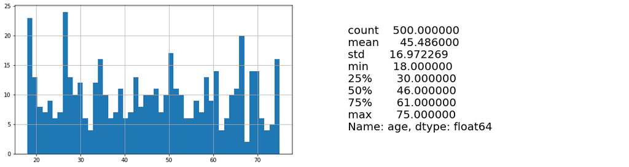

```python
#Analizamos la edad de los usuarios buscando algun valor atipico
fig, (ax1, ax2) = plt.subplots(nrows=1, ncols=2, figsize=(20, 8))
data_users['age'].hist(ax=ax1,bins=50, figsize=(20,5))

ax2.axis('off')
ax2.text(0, 0.5, str(data_users['age'].describe()), fontsize=20, va='center')
plt.show()
```

Analizando el histograma, no se ve ninguna edad fuera de los normal. Las mayoria de los usuarios rondan los 45 años, con usuarios con edades entre 18 y 75 años.

### Corregir datos

Como ya se mencionó anteriormnete, es necesario transformar `reg_date` y `churn_date` de tipo object a tipo datetime.

```python
data_users['reg_date'] = pd.to_datetime(data_users['reg_date'], format='%Y-%m-%d')
data_users['churn_date'] = pd.to_datetime(data_users['churn_date'], format='%Y-%m-%d')
data_users.info()
```

```
<class 'pandas.core.frame.DataFrame'>
RangeIndex: 500 entries, 0 to 499
Data columns (total 8 columns):
 #   Column      Non-Null Count  Dtype
---  ------      --------------  -----
 0   user_id     500 non-null    int64
 1   first_name  500 non-null    object
 2   last_name   500 non-null    object
 3   age         500 non-null    int64
 4   city        500 non-null    object
 5   reg_date    500 non-null    datetime64[ns]
 6   plan        500 non-null    object
 7   churn_date  34 non-null     datetime64[ns]
dtypes: datetime64[ns](2), int64(2), object(4)
memory usage: 31.4+ KB
```

### Enriquecer datos

Enriquecemos nuestro Dataframe, agregando columnas que registren el mes de inicio (`mes_inicio`) de plan y mes de termino (`mes_termino`) (si es que lo terminaron). Adempas, separamos `city` en donde columnas, una que almacena las `ciudades` y otra los `estados`

```python
#Separo city por ciudades y por estado
data_users['ciudades']=data_users['city'].str.split(',', n=1, expand=True)[0]

#Dado que todos los valores terminan en MSA (Áreas Estadísticas Metropolitanas) elimino los ultimos 3 caracteres
data_users['estado']=data_users['city'].str.split(',', n=1, expand=True)[1].str.slice(stop=-3)

#Registramos mes de inicio del plan
data_users['mes_inicio'] = data_users['reg_date'].dt.month.astype(str).str.zfill(2) #transformo a cadena con formato 00
#Registramos mes de fin del plan (si es que lo finalizó)
data_users['mes_fin'] = data_users['churn_date'].dt.month
data_users.head(10)
```

|  | user_id | first_name | last_name | age | city | reg_date | plan | churn_date | ciudades | estado | mes_inicio | mes_fin |
| --- | --- | --- | --- | --- | --- | --- | --- | --- | --- | --- | --- | --- |
| 0 | 1000 | Anamaria | Bauer | 45 | Atlanta-Sandy Springs-Roswell, GA MSA | 2018-12-24 | ultimate | NaT | Atlanta-Sandy Springs-Roswell | GA | 12 | NaN |
| 1 | 1001 | Mickey | Wilkerson | 28 | Seattle-Tacoma-Bellevue, WA MSA | 2018-08-13 | surf | NaT | Seattle-Tacoma-Bellevue | WA | 08 | NaN |
| 2 | 1002 | Carlee | Hoffman | 36 | Las Vegas-Henderson-Paradise, NV MSA | 2018-10-21 | surf | NaT | Las Vegas-Henderson-Paradise | NV | 10 | NaN |
| 3 | 1003 | Reynaldo | Jenkins | 52 | Tulsa, OK MSA | 2018-01-28 | surf | NaT | Tulsa | OK | 01 | NaN |
| 4 | 1004 | Leonila | Thompson | 40 | Seattle-Tacoma-Bellevue, WA MSA | 2018-05-23 | surf | NaT | Seattle-Tacoma-Bellevue | WA | 05 | NaN |
| 5 | 1005 | Livia | Shields | 31 | Dallas-Fort Worth-Arlington, TX MSA | 2018-11-29 | surf | NaT | Dallas-Fort Worth-Arlington | TX | 11 | NaN |
| 6 | 1006 | Jesusa | Bradford | 73 | San Francisco-Oakland-Berkeley, CA MSA | 2018-11-27 | ultimate | 2018-12-18 | San Francisco-Oakland-Berkeley | CA | 11 | 12.0 |
| 7 | 1007 | Eusebio | Welch | 42 | Grand Rapids-Kentwood, MI MSA | 2018-07-11 | surf | NaT | Grand Rapids-Kentwood | MI | 07 | NaN |
| 8 | 1008 | Emely | Hoffman | 53 | Orlando-Kissimmee-Sanford, FL MSA | 2018-08-03 | ultimate | NaT | Orlando-Kissimmee-Sanford | FL | 08 | NaN |
| 9 | 1009 | Gerry | Little | 19 | San Jose-Sunnyvale-Santa Clara, CA MSA | 2018-04-22 | surf | NaT | San Jose-Sunnyvale-Santa Clara | CA | 04 | NaN |

## Llamadas

```python
# Imprimimos una muestra de datos para llamadas
data_calls.head(10)
```

|  | id | user_id | call_date | duration |
| --- | --- | --- | --- | --- |
| 0 | 1000_93 | 1000 | 2018-12-27 | 8.52 |
| 1 | 1000_145 | 1000 | 2018-12-27 | 13.66 |
| 2 | 1000_247 | 1000 | 2018-12-27 | 14.48 |
| 3 | 1000_309 | 1000 | 2018-12-28 | 5.76 |
| 4 | 1000_380 | 1000 | 2018-12-30 | 4.22 |
| 5 | 1000_388 | 1000 | 2018-12-31 | 2.20 |
| 6 | 1000_510 | 1000 | 2018-12-27 | 5.75 |
| 7 | 1000_521 | 1000 | 2018-12-28 | 14.18 |
| 8 | 1000_530 | 1000 | 2018-12-28 | 5.77 |
| 9 | 1000_544 | 1000 | 2018-12-26 | 4.40 |

### Corregir datos

Como ya se mencionó anteriormnete, es necesario transformar `call_date` de tipo object a tipo datetime.

```python
data_calls['call_date'] = pd.to_datetime(data_calls['call_date'], format='%Y-%m-%d')
data_calls.info()
```

```
<class 'pandas.core.frame.DataFrame'>
RangeIndex: 137735 entries, 0 to 137734
Data columns (total 4 columns):
 #   Column     Non-Null Count   Dtype
---  ------     --------------   -----
 0   id         137735 non-null  object
 1   user_id    137735 non-null  int64
 2   call_date  137735 non-null  datetime64[ns]
 3   duration   137735 non-null  float64
dtypes: datetime64[ns](1), float64(1), int64(1), object(1)
memory usage: 4.2+ MB
```

### Enriquecer datos

Enriquecemos nuestro Dataframe, agregando columnas que registren el id de llamada (`id_llamada`), el dia de la semana (`dia_semana`) y mes (`mes`) en el que se realizo cada llamada. Ademas, creamos una columna que aproxima la duración de cada llamada a la cifra mas alta, tal y como la compañia que especifica `duracion_redondeada` y que se utilizará mas adelante para calcular los cobros por usuario.

```python
#cada llamada individual se redondea: incluso si la llamada duró solo un segundo, se contará como un minuto
#data_calls['duracion_redondeada'] = data_calls['duration'].apply(lambda x: math.ceil(x))
data_calls['duracion_redondeada'] = data_calls['duration'].apply(lambda x: np.ceil(x))

data_calls['id_llamada']=data_calls['id'].str.split('_', n=1, expand=True)[1]
data_calls['dia_semana'] = data_calls['call_date'].dt.dayofweek
data_calls['mes'] = data_calls['call_date'].dt.month.astype(str).str.zfill(2) #transformo a cadena con formato 00
data_calls.head(10)
```

|  | id | user_id | call_date | duration | duracion_redondeada | id_llamada | dia_semana | mes |
| --- | --- | --- | --- | --- | --- | --- | --- | --- |
| 0 | 1000_93 | 1000 | 2018-12-27 | 8.52 | 9.0 | 93 | 3 | 12 |
| 1 | 1000_145 | 1000 | 2018-12-27 | 13.66 | 14.0 | 145 | 3 | 12 |
| 2 | 1000_247 | 1000 | 2018-12-27 | 14.48 | 15.0 | 247 | 3 | 12 |
| 3 | 1000_309 | 1000 | 2018-12-28 | 5.76 | 6.0 | 309 | 4 | 12 |
| 4 | 1000_380 | 1000 | 2018-12-30 | 4.22 | 5.0 | 380 | 6 | 12 |
| 5 | 1000_388 | 1000 | 2018-12-31 | 2.20 | 3.0 | 388 | 0 | 12 |
| 6 | 1000_510 | 1000 | 2018-12-27 | 5.75 | 6.0 | 510 | 3 | 12 |
| 7 | 1000_521 | 1000 | 2018-12-28 | 14.18 | 15.0 | 521 | 4 | 12 |
| 8 | 1000_530 | 1000 | 2018-12-28 | 5.77 | 6.0 | 530 | 4 | 12 |
| 9 | 1000_544 | 1000 | 2018-12-26 | 4.40 | 5.0 | 544 | 2 | 12 |

## Mensajes

```python
# Imprimimos una muestra de datos para los mensajes
data_messages.head(10)
```

|  | id | user_id | message_date |
| --- | --- | --- | --- |
| 0 | 1000_125 | 1000 | 2018-12-27 |
| 1 | 1000_160 | 1000 | 2018-12-31 |
| 2 | 1000_223 | 1000 | 2018-12-31 |
| 3 | 1000_251 | 1000 | 2018-12-27 |
| 4 | 1000_255 | 1000 | 2018-12-26 |
| 5 | 1000_346 | 1000 | 2018-12-29 |
| 6 | 1000_386 | 1000 | 2018-12-30 |
| 7 | 1000_413 | 1000 | 2018-12-31 |
| 8 | 1000_502 | 1000 | 2018-12-27 |
| 9 | 1000_525 | 1000 | 2018-12-28 |

### Corregir datos

Como ya se mencionó anteriormnete, es necesario transformar `message_date` de tipo object a tipo datetime.

```python
data_messages['message_date'] = pd.to_datetime(data_messages['message_date'], format='%Y-%m-%d')
data_messages.info()
```

```
<class 'pandas.core.frame.DataFrame'>
RangeIndex: 76051 entries, 0 to 76050
Data columns (total 3 columns):
 #   Column        Non-Null Count  Dtype
---  ------        --------------  -----
 0   id            76051 non-null  object
 1   user_id       76051 non-null  int64
 2   message_date  76051 non-null  datetime64[ns]
dtypes: datetime64[ns](1), int64(1), object(1)
memory usage: 1.7+ MB
```

### Enriquecer datos

Enriquecemos nuestro Dataframe, agregando columnas que registren el id de mensaje (`id_mensaje`), el dia de la semana (`dia_semana`) y mes (`mes`) en el que se envio el mensaje.

```python
data_messages['id_mensaje']= data_messages['id'].str.split('_', n=1, expand=True)[1]
data_messages['dia_semana'] = data_messages['message_date'].dt.dayofweek
data_messages['mes'] = data_messages['message_date'].dt.month.astype(str).str.zfill(2) #transformo a cadena con formato 00
data_messages.head(10)
```

|  | id | user_id | message_date | id_mensaje | dia_semana | mes |
| --- | --- | --- | --- | --- | --- | --- |
| 0 | 1000_125 | 1000 | 2018-12-27 | 125 | 3 | 12 |
| 1 | 1000_160 | 1000 | 2018-12-31 | 160 | 0 | 12 |
| 2 | 1000_223 | 1000 | 2018-12-31 | 223 | 0 | 12 |
| 3 | 1000_251 | 1000 | 2018-12-27 | 251 | 3 | 12 |
| 4 | 1000_255 | 1000 | 2018-12-26 | 255 | 2 | 12 |
| 5 | 1000_346 | 1000 | 2018-12-29 | 346 | 5 | 12 |
| 6 | 1000_386 | 1000 | 2018-12-30 | 386 | 6 | 12 |
| 7 | 1000_413 | 1000 | 2018-12-31 | 413 | 0 | 12 |
| 8 | 1000_502 | 1000 | 2018-12-27 | 502 | 3 | 12 |
| 9 | 1000_525 | 1000 | 2018-12-28 | 525 | 4 | 12 |

## Internet

```python
# Imprimimos una muestra de datos para el tráfico de internet
data_internet.head(10)
```

|  | id | user_id | session_date | mb_used |
| --- | --- | --- | --- | --- |
| 0 | 1000_13 | 1000 | 2018-12-29 | 89.86 |
| 1 | 1000_204 | 1000 | 2018-12-31 | 0.00 |
| 2 | 1000_379 | 1000 | 2018-12-28 | 660.40 |
| 3 | 1000_413 | 1000 | 2018-12-26 | 270.99 |
| 4 | 1000_442 | 1000 | 2018-12-27 | 880.22 |
| 5 | 1001_0 | 1001 | 2018-08-24 | 284.68 |
| 6 | 1001_3 | 1001 | 2018-12-09 | 656.04 |
| 7 | 1001_4 | 1001 | 2018-11-04 | 16.97 |
| 8 | 1001_10 | 1001 | 2018-11-27 | 135.18 |
| 9 | 1001_15 | 1001 | 2018-12-13 | 761.92 |

### Corregir datos

Como ya se mencionó anteriormnete, es necesario transformar `session_date` de tipo object a tipo datetime.

```python
data_internet['session_date'] = pd.to_datetime(data_internet['session_date'], format='%Y-%m-%d')
data_messages.info()
```

```
<class 'pandas.core.frame.DataFrame'>
RangeIndex: 76051 entries, 0 to 76050
Data columns (total 6 columns):
 #   Column        Non-Null Count  Dtype
---  ------        --------------  -----
 0   id            76051 non-null  object
 1   user_id       76051 non-null  int64
 2   message_date  76051 non-null  datetime64[ns]
 3   id_mensaje    76051 non-null  object
 4   dia_semana    76051 non-null  int64
 5   mes           76051 non-null  object
dtypes: datetime64[ns](1), int64(2), object(3)
memory usage: 3.5+ MB
```

### Enriquecer datos

Enriquecemos nuestro Dataframe, agregando columnas que registran el id de sesión (`id_session`), el dia de la semana (`dia_semana`) y mes (`mes`) de la sesión.

```python
data_internet['id_session']= data_internet['id'].str.split('_', n=1, expand=True)[1]
data_internet['dia_semana'] = data_internet['session_date'].dt.dayofweek
data_internet['mes'] = data_internet['session_date'].dt.month.astype(str).str.zfill(2) #transformo a cadena con formato 00
data_internet.head(10)
```

|  | id | user_id | session_date | mb_used | id_session | dia_semana | mes |
| --- | --- | --- | --- | --- | --- | --- | --- |
| 0 | 1000_13 | 1000 | 2018-12-29 | 89.86 | 13 | 5 | 12 |
| 1 | 1000_204 | 1000 | 2018-12-31 | 0.00 | 204 | 0 | 12 |
| 2 | 1000_379 | 1000 | 2018-12-28 | 660.40 | 379 | 4 | 12 |
| 3 | 1000_413 | 1000 | 2018-12-26 | 270.99 | 413 | 2 | 12 |
| 4 | 1000_442 | 1000 | 2018-12-27 | 880.22 | 442 | 3 | 12 |
| 5 | 1001_0 | 1001 | 2018-08-24 | 284.68 | 0 | 4 | 08 |
| 6 | 1001_3 | 1001 | 2018-12-09 | 656.04 | 3 | 6 | 12 |
| 7 | 1001_4 | 1001 | 2018-11-04 | 16.97 | 4 | 6 | 11 |
| 8 | 1001_10 | 1001 | 2018-11-27 | 135.18 | 10 | 1 | 11 |
| 9 | 1001_15 | 1001 | 2018-12-13 | 761.92 | 15 | 3 | 12 |

## Estudiamos nuevamente las condiciones del plan

```python
# Imprimimos las condiciones del plan y asegúrate de que te resulten claros
data_plans
```

|  | messages_included | mb_per_month_included | minutes_included | usd_monthly_pay | usd_per_gb | usd_per_message | usd_per_minute | plan_name |
| --- | --- | --- | --- | --- | --- | --- | --- | --- |
| 0 | 50 | 15360 | 500 | 20 | 10 | 0.03 | 0.03 | surf |
| 1 | 1000 | 30720 | 3000 | 70 | 7 | 0.01 | 0.01 | ultimate |

**Surf**  
Pago mensual: 20 USD  
500 minutos al mes, 50 SMS y 15 GB de datos (1GB=1024mb)  
Si se exceden los límites del paquete:  
1 minuto: 3 centavos  
1 SMS: 3 centavos  
1 GB de datos: 10 USD

## Agregamos datos por usuario

Procedemos a calcular la cantidad de llamadas realizadas, la duración total de llamadas, los mensajes enviados y los datos consumidos por cada usuario en un mes.

```python
# Calculamos el número de llamadas hechas por cada usuario por mes y guardamos el resultado.

numero_llamadas=data_calls.pivot_table(index=('user_id','mes'),values='id',aggfunc=('count'))
numero_llamadas = numero_llamadas.rename(columns={'id': 'num_llamadas'})
numero_llamadas
```

| user_id | mes | num_llamadas |
| --- | --- | --- |
| 1000 | 12 | 16 |
| 1001 | 08 | 27 |
|  | 09 | 49 |
|  | 10 | 65 |
|  | 11 | 64 |
| ... | ... | ... |
| 1498 | 12 | 39 |
| 1499 | 09 | 41 |
|  | 10 | 53 |
|  | 11 | 45 |
|  | 12 | 65 |

2258 rows × 1 columns

```python
# Calculamos la cantidad de minutos que usó cada usuario por mes y guardamos el resultado.
minutos=data_calls.pivot_table(index=('user_id','mes'), values='duracion_redondeada',aggfunc=('sum'))
minutos
```

| user_id | mes | duracion_redondeada |
| --- | --- | --- |
| 1000 | 12 | 124.0 |
| 1001 | 08 | 182.0 |
|  | 09 | 315.0 |
|  | 10 | 393.0 |
|  | 11 | 426.0 |
| ... | ... | ... |
| 1498 | 12 | 339.0 |
| 1499 | 09 | 346.0 |
|  | 10 | 385.0 |
|  | 11 | 308.0 |
|  | 12 | 496.0 |

2258 rows × 1 columns

```python
# Calculamos el número de mensajes enviados por cada usuario por mes y guardamos el resultado.
numero_mensajes=data_messages.pivot_table(index=('user_id','mes'), values='id',aggfunc=('count'))
numero_mensajes = numero_mensajes.rename(columns={'id': 'num_mensajes'})
numero_mensajes
```

| user_id | mes | num_mensajes |
| --- | --- | --- |
| 1000 | 12 | 11 |
| 1001 | 08 | 30 |
|  | 09 | 44 |
|  | 10 | 53 |
|  | 11 | 36 |
| ... | ... | ... |
| 1496 | 09 | 21 |
|  | 10 | 18 |
|  | 11 | 13 |
|  | 12 | 11 |
| 1497 | 12 | 50 |

1806 rows × 1 columns

```python
# Calculamos el volumen del trafico de internet usado por cada usuario por mes y guarda el resultado.
gb_usados=data_internet.pivot_table(index=('user_id','mes'), values='mb_used',aggfunc=('sum'))
gb_usados
```

| user_id | mes | mb_used |
| --- | --- | --- |
| 1000 | 12 | 1901.47 |
| 1001 | 08 | 6919.15 |
|  | 09 | 13314.82 |
|  | 10 | 22330.49 |
|  | 11 | 18504.30 |
| ... | ... | ... |
| 1498 | 12 | 23137.69 |
| 1499 | 09 | 12984.76 |
|  | 10 | 19492.43 |
|  | 11 | 16813.83 |
|  | 12 | 22059.21 |

2277 rows × 1 columns

Combinamos todos los data frames antes construidos en uno solo llamaado "Consumo usuarios" el cual almacena el consumo general de cada usuario por mes.

```python
# Combinamos los datos para las llamadas, minutos, mensajes e internet con base en el user_id y el mes

#consumo_usuarios=numero_llamadas.join(minutos, on=['user_id', 'mes']).fillna(0)
#consumo_usuarios=consumo_usuarios.join(numero_mensajes, on=['user_id', 'mes'])
#consumo_usuarios=consumo_usuarios.join(gb_usados, on=['user_id', 'mes']).fillna(0)
#consumo_usuarios=consumo_usuarios.sort_values(by=['user_id', 'mes'])

consumo_usuarios=pd.concat([numero_llamadas, minutos, numero_mensajes, gb_usados], axis=1).fillna(0)
consumo_usuarios
```

| user_id | mes | num_llamadas | duracion_redondeada | num_mensajes | mb_used |
| --- | --- | --- | --- | --- | --- |
| 1000 | 12 | 16.0 | 124.0 | 11.0 | 1901.47 |
| 1001 | 08 | 27.0 | 182.0 | 30.0 | 6919.15 |
|  | 09 | 49.0 | 315.0 | 44.0 | 13314.82 |
|  | 10 | 65.0 | 393.0 | 53.0 | 22330.49 |
|  | 11 | 64.0 | 426.0 | 36.0 | 18504.30 |
| ... | ... | ... | ... | ... | ... |
| 1498 | 12 | 39.0 | 339.0 | 0.0 | 23137.69 |
| 1499 | 09 | 41.0 | 346.0 | 0.0 | 12984.76 |
|  | 10 | 53.0 | 385.0 | 0.0 | 19492.43 |
|  | 11 | 45.0 | 308.0 | 0.0 | 16813.83 |
|  | 12 | 65.0 | 496.0 | 0.0 | 22059.21 |

2293 rows × 4 columns

```python
# Añadimos la información del plan

#Creo un dataframe auxiliar que solo contiene las columnas user_id, plan, mes_inicio y mes_fin
data_users_plan=data_users.loc[:,['user_id','plan','mes_inicio','mes_fin']]

#Inicializó una nueva columna llamada 'mes'
data_users_plan['mes']=''

#recorro el data frame por index
for index, row in data_users_plan.iterrows():

    #almaceno el mes_inicio, user_id y plan de la fila en caad loop
    mes_inicio=int(data_users_plan['mes_inicio'].loc[index])
    user_id= data_users_plan['user_id'].loc[index]
    plan=data_users_plan['plan'].loc[index]

    #si es posible (si no es NaN) almaceno el mes_fin, si no se puede, lo definimos en 12
    try:mes_fin=int(data_users_plan['mes_fin'].loc[index])  #intentamos calcular el mes de final de contrato
    except: mes_fin=12    #si es nan no se puede calcular y se define 12

    #A nuestro dataframe auxiliar, agrego columnas por cada mes que el usuario tiene el plan
    #Por ejemplo, si el mes_inicio es 3 y mes_fin es 7 entonces agregamos los meses 4,5,6 y 7 con el plan correspondiente

    for i in range(mes_inicio+1,mes_fin+1):
        data_users_plan = data_users_plan.append({'user_id':user_id,'plan': plan,'mes': f'{i:02}'}, ignore_index=True)

    data_users_plan.at[index, 'mes'] = f'{mes_inicio:02}'

meses_plan=data_users_plan.pivot_table(index=('user_id','mes'),values=('plan'),aggfunc=('first'))
meses_plan.head(10)
```

| user_id | mes | plan |
| --- | --- | --- |
| 1000 | 12 | ultimate |
| 1001 | 08 | surf |
|  | 09 | surf |
|  | 10 | surf |
|  | 11 | surf |
|  | 12 | surf |
| 1002 | 10 | surf |
|  | 11 | surf |
|  | 12 | surf |
| 1003 | 01 | surf |

```python
prueba = pd.merge(consumo_usuarios, data_users[['user_id', 'plan']],on='user_id')
prueba.head(5)
```

|  | user_id | num_llamadas | duracion_redondeada | num_mensajes | mb_used | plan |
| --- | --- | --- | --- | --- | --- | --- |
| 0 | 1000 | 16.0 | 124.0 | 11.0 | 1901.47 | ultimate |
| 1 | 1001 | 27.0 | 182.0 | 30.0 | 6919.15 | surf |
| 2 | 1001 | 49.0 | 315.0 | 44.0 | 13314.82 | surf |
| 3 | 1001 | 65.0 | 393.0 | 53.0 | 22330.49 | surf |
| 4 | 1001 | 64.0 | 426.0 | 36.0 | 18504.30 | surf |

```python
# Combinamos el dataframe antes obtenido con nuestro dataframe de consumo por mes
# De esta forma sabemos que plan tenia el usuario en cada mes
consumo_usuarios=consumo_usuarios.join(meses_plan, on=['user_id', 'mes']).fillna('cancelado')
print_mejorado("consumo_usuarios tiene "+ str(len(consumo_usuarios)) + " filas",24)
consumo_usuarios
```

consumo_usuarios tiene 2293 filas

| user_id | mes | num_llamadas | duracion_redondeada | num_mensajes | mb_used | plan |
| --- | --- | --- | --- | --- | --- | --- |
| 1000 | 12 | 16.0 | 124.0 | 11.0 | 1901.47 | ultimate |
| 1001 | 08 | 27.0 | 182.0 | 30.0 | 6919.15 | surf |
|  | 09 | 49.0 | 315.0 | 44.0 | 13314.82 | surf |
|  | 10 | 65.0 | 393.0 | 53.0 | 22330.49 | surf |
|  | 11 | 64.0 | 426.0 | 36.0 | 18504.30 | surf |
| ... | ... | ... | ... | ... | ... | ... |
| 1498 | 12 | 39.0 | 339.0 | 0.0 | 23137.69 | surf |
| 1499 | 09 | 41.0 | 346.0 | 0.0 | 12984.76 | surf |
|  | 10 | 53.0 | 385.0 | 0.0 | 19492.43 | surf |
|  | 11 | 45.0 | 308.0 | 0.0 | 16813.83 | surf |
|  | 12 | 65.0 | 496.0 | 0.0 | 22059.21 | surf |

2293 rows × 5 columns

Dado que el dataframe **meses** solo considera los meses en los que el usuario registro actividad (llamadas, mensajes o datos) y al mismo tiempo estaba dentro del rango de contratación **mes_inicio<=data<=mes_fin**. Entonces a continuación, tras usar Join entre **consumo_usuarios** y **meses**, los valores que aparezcan como NaN seran remplazados con *cancelado* (Plan cancelado) para posteriormente no contabilizar estas filas en el analisis.

Comprobamos los 34 usuarios que cancelaron el plan

```python
#Buscamos usuarios que hayan cancelado el plan
data_users[~data_users['churn_date'].isna()]['user_id'].unique()
```

```
array([1006, 1012, 1022, 1040, 1050, 1054, 1067, 1083, 1084, 1094, 1106,
       1129, 1172, 1180, 1186, 1191, 1220, 1246, 1269, 1281, 1296, 1298,
       1300, 1315, 1358, 1363, 1402, 1414, 1416, 1441, 1451, 1466, 1467,
       1491])
```

```python
data_users[~data_users['churn_date'].isna()].query('user_id==(1022,1050,1441,1466)')
```

|  | user_id | first_name | last_name | age | city | reg_date | plan | churn_date | ciudades | estado | mes_inicio | mes_fin |
| --- | --- | --- | --- | --- | --- | --- | --- | --- | --- | --- | --- | --- |
| 22 | 1022 | Bo | Snow | 73 | New York-Newark-Jersey City, NY-NJ-PA MSA | 2018-04-20 | surf | 2018-09-07 | New York-Newark-Jersey City | NY-NJ-PA | 04 | 9.0 |
| 50 | 1050 | Jone | Owen | 23 | Miami-Fort Lauderdale-West Palm Beach, FL MSA | 2018-03-20 | ultimate | 2018-10-07 | Miami-Fort Lauderdale-West Palm Beach | FL | 03 | 10.0 |
| 441 | 1441 | Piedad | Myers | 23 | Atlanta-Sandy Springs-Roswell, GA MSA | 2018-03-08 | ultimate | 2018-08-19 | Atlanta-Sandy Springs-Roswell | GA | 03 | 8.0 |
| 466 | 1466 | Alphonse | Harmon | 56 | Los Angeles-Long Beach-Anaheim, CA MSA | 2018-01-26 | surf | 2018-09-17 | Los Angeles-Long Beach-Anaheim | CA | 01 | 9.0 |

```python
#Nos aseguramos que algunos de los usuarios que cancelaron antes, aparezca "cancelado"
consumo_usuarios.query('user_id==(1022,1050,1441,1466)')
```

| user_id | mes | num_llamadas | duracion_redondeada | num_mensajes | mb_used | plan |
| --- | --- | --- | --- | --- | --- | --- |
| 1022 | 05 | 39.0 | 302.0 | 0.0 | 4908.08 | surf |
|  | 06 | 76.0 | 490.0 | 0.0 | 23436.48 | surf |
|  | 07 | 70.0 | 475.0 | 0.0 | 9933.15 | surf |
|  | 08 | 80.0 | 631.0 | 0.0 | 21325.33 | surf |
|  | 09 | 66.0 | 510.0 | 0.0 | 14118.23 | surf |
|  | 10 | 83.0 | 574.0 | 0.0 | 18961.41 | cancelado |
|  | 11 | 72.0 | 498.0 | 0.0 | 22204.48 | cancelado |
|  | 12 | 82.0 | 585.0 | 0.0 | 18283.62 | cancelado |
| 1050 | 03 | 23.0 | 135.0 | 0.0 | 5942.60 | ultimate |
|  | 04 | 50.0 | 353.0 | 0.0 | 17557.58 | ultimate |
|  | 05 | 62.0 | 418.0 | 0.0 | 16769.29 | ultimate |
|  | 06 | 55.0 | 471.0 | 0.0 | 11574.00 | ultimate |
|  | 07 | 63.0 | 430.0 | 0.0 | 16132.82 | ultimate |
|  | 08 | 51.0 | 358.0 | 0.0 | 15211.45 | ultimate |
|  | 09 | 57.0 | 371.0 | 0.0 | 16997.27 | ultimate |
|  | 10 | 53.0 | 307.0 | 0.0 | 24534.68 | ultimate |
|  | 11 | 57.0 | 413.0 | 0.0 | 14227.19 | cancelado |
|  | 12 | 52.0 | 299.0 | 0.0 | 17044.12 | cancelado |
| 1441 | 11 | 43.0 | 345.0 | 7.0 | 8406.23 | cancelado |
|  | 12 | 139.0 | 987.0 | 15.0 | 28844.55 | cancelado |
| 1466 | 05 | 11.0 | 50.0 | 25.0 | 7127.48 | surf |
|  | 06 | 31.0 | 206.0 | 29.0 | 12559.35 | surf |
|  | 07 | 24.0 | 128.0 | 40.0 | 19761.29 | surf |
|  | 08 | 31.0 | 171.0 | 46.0 | 14284.36 | surf |
|  | 09 | 26.0 | 194.0 | 50.0 | 17916.48 | surf |
|  | 10 | 33.0 | 238.0 | 51.0 | 14944.62 | cancelado |
|  | 11 | 28.0 | 202.0 | 38.0 | 13191.03 | cancelado |
|  | 12 | 32.0 | 254.0 | 41.0 | 11303.25 | cancelado |

```python
#Nos aseguramos que algunos de los usuarios que cancelaron antes, aparezca "cancelado"
print_mejorado(str(len(consumo_usuarios.query('plan=="cancelado"'))) + " meses donde usuarios registraron actividad posterior a haber cancelado el plan",24)
consumo_usuarios.query('plan=="cancelado"')
```

37 meses donde usuarios registraron actividad posterior a haber cancelado el plan

| user_id | mes | num_llamadas | duracion_redondeada | num_mensajes | mb_used | plan |
| --- | --- | --- | --- | --- | --- | --- |
| 1012 | 12 | 16.0 | 78.0 | 0.0 | 11876.94 | cancelado |
| 1022 | 10 | 83.0 | 574.0 | 0.0 | 18961.41 | cancelado |
|  | 11 | 72.0 | 498.0 | 0.0 | 22204.48 | cancelado |
|  | 12 | 82.0 | 585.0 | 0.0 | 18283.62 | cancelado |
| 1050 | 11 | 57.0 | 413.0 | 0.0 | 14227.19 | cancelado |
|  | 12 | 52.0 | 299.0 | 0.0 | 17044.12 | cancelado |
| 1067 | 12 | 53.0 | 344.0 | 20.0 | 15944.51 | cancelado |
| 1084 | 12 | 103.0 | 720.0 | 81.0 | 27859.08 | cancelado |
| 1106 | 12 | 67.0 | 569.0 | 0.0 | 22147.94 | cancelado |
| 1172 | 12 | 90.0 | 711.0 | 117.0 | 23662.21 | cancelado |
| 1191 | 12 | 85.0 | 625.0 | 10.0 | 11702.26 | cancelado |
| 1220 | 11 | 76.0 | 487.0 | 25.0 | 12919.69 | cancelado |
|  | 12 | 88.0 | 558.0 | 31.0 | 18578.62 | cancelado |
| 1246 | 08 | 96.0 | 698.0 | 15.0 | 18177.28 | cancelado |
|  | 09 | 40.0 | 321.0 | 8.0 | 7999.39 | cancelado |
| 1281 | 12 | 88.0 | 645.0 | 38.0 | 8169.07 | cancelado |
| 1315 | 11 | 33.0 | 282.0 | 21.0 | 7555.01 | cancelado |
|  | 12 | 43.0 | 350.0 | 35.0 | 5856.48 | cancelado |
| 1358 | 11 | 58.0 | 445.0 | 4.0 | 16537.90 | cancelado |
|  | 12 | 4.0 | 18.0 | 0.0 | 3106.00 | cancelado |
| 1363 | 09 | 36.0 | 301.0 | 27.0 | 10327.62 | cancelado |
|  | 10 | 49.0 | 385.0 | 41.0 | 16992.86 | cancelado |
|  | 11 | 39.0 | 258.0 | 34.0 | 16635.67 | cancelado |
|  | 12 | 40.0 | 262.0 | 42.0 | 18225.67 | cancelado |
| 1414 | 10 | 67.0 | 546.0 | 70.0 | 25002.88 | cancelado |
|  | 11 | 57.0 | 288.0 | 38.0 | 26856.13 | cancelado |
|  | 12 | 65.0 | 451.0 | 54.0 | 30361.91 | cancelado |
| 1416 | 12 | 49.0 | 398.0 | 49.0 | 35061.14 | cancelado |
| 1441 | 11 | 43.0 | 345.0 | 7.0 | 8406.23 | cancelado |
|  | 12 | 139.0 | 987.0 | 15.0 | 28844.55 | cancelado |
| 1466 | 10 | 33.0 | 238.0 | 51.0 | 14944.62 | cancelado |
|  | 11 | 28.0 | 202.0 | 38.0 | 13191.03 | cancelado |
|  | 12 | 32.0 | 254.0 | 41.0 | 11303.25 | cancelado |
| 1467 | 12 | 66.0 | 483.0 | 77.0 | 18368.02 | cancelado |
| 1491 | 10 | 75.0 | 585.0 | 51.0 | 8480.09 | cancelado |
|  | 11 | 46.0 | 409.0 | 46.0 | 5185.73 | cancelado |
|  | 12 | 55.0 | 399.0 | 43.0 | 6766.42 | cancelado |

Analizando la tabla anterior, vemos que existen algunos usuarios que tiene registro de llamadas, mensajes o datos, para fechas posteriores a la fecha de cancelación del plan. Los meses en lo que esto sucede fueron etiquetados como *cancelado* y para los analisis posteriores seran descartados.

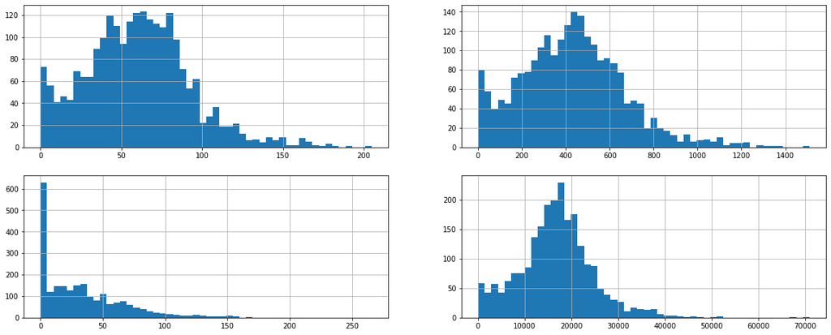

```
['ultimate' 'surf' 'cancelado']
```

```python
#Observamos la distribución de las llamadas, duración, mensajes y consumo de datos para todos los usuarios
fig, axs = plt.subplots(nrows=2, ncols=2, figsize=(20, 8))
consumo_usuarios['num_llamadas'].hist(ax=axs[0,0],bins=50)
consumo_usuarios['duracion_redondeada'].hist(ax=axs[0,1],bins=50)
consumo_usuarios['num_mensajes'].hist(ax=axs[1,0],bins=50)
consumo_usuarios['mb_used'].hist(ax=axs[1,1],bins=50)
plt.show()

#Verificamos que solo existan 3 condiciones de plan, Surf, Ultimate y Cancelado
print(consumo_usuarios['plan'].unique())
```

**Surf**  
Pago mensual: 20 USD  
500 minutos al mes, 50 SMS y 15 GB de datos (1GB=1024mb)  
Si se exceden los límites del paquete:  
1 minuto: 3 centavos  
1 SMS: 3 centavos  
1 GB de datos: 10 USD

## Calculo de ingreso mensual por usuario

*Calculamos el ingreso mensual por usuario, en base a la información especificada arriba.*

```python
# Calculamos el ingreso mensual para cada usuario

#Construyo una función que calcule el ingreso segun el plan y el consumo mensual
def calculo_ingresos(df):
    plan=df['plan']
    llamadas=df['num_llamadas']
    minutos=df['duracion_redondeada']
    mensajes=df['num_mensajes']
    gb_usados=math.ceil(df['mb_used']/1024)

    ingresos=0

    if plan == 'surf':
        ingresos=20
        if minutos>500:
            ingresos=ingresos+(minutos-500)*0.03
        if mensajes>50:
            ingresos=ingresos+(mensajes-50)*0.03
        if gb_usados>15:
            ingresos=ingresos+(gb_usados-15)*10
        return ingresos

    if plan == 'ultimate':
        ingresos=70
        if minutos>3000:
            ingresos=ingresos+(minutos-3000)*0.01
        if mensajes>1000:
            ingresos=ingresos+(mensajes-1000)*0.01
        if gb_usados>30:
            ingresos=ingresos+(gb_usados-30)*7
        return ingresos

    if plan == 'cancelado':
        return 0

#Aplicamos nuestra función con el metodo apply y almacenamos el resultado en una nueva columna llamada 'ingresos'
consumo_usuarios['ingresos'] = consumo_usuarios.apply(calculo_ingresos, axis=1)

consumo_usuarios.head(100)
```

| user_id | mes | num_llamadas | duracion_redondeada | num_mensajes | mb_used | plan | ingresos |
| --- | --- | --- | --- | --- | --- | --- | --- |
| 1000 | 12 | 16.0 | 124.0 | 11.0 | 1901.47 | ultimate | 70.00 |
| 1001 | 08 | 27.0 | 182.0 | 30.0 | 6919.15 | surf | 20.00 |
|  | 09 | 49.0 | 315.0 | 44.0 | 13314.82 | surf | 20.00 |
|  | 10 | 65.0 | 393.0 | 53.0 | 22330.49 | surf | 90.09 |
|  | 11 | 64.0 | 426.0 | 36.0 | 18504.30 | surf | 60.00 |
|  | 12 | 56.0 | 412.0 | 44.0 | 19369.18 | surf | 60.00 |
| 1002 | 10 | 11.0 | 59.0 | 15.0 | 6552.01 | surf | 20.00 |
|  | 11 | 55.0 | 386.0 | 32.0 | 19345.08 | surf | 60.00 |
|  | 12 | 47.0 | 384.0 | 41.0 | 14396.24 | surf | 20.00 |
| 1003 | 12 | 149.0 | 1104.0 | 50.0 | 27044.14 | surf | 158.12 |
| 1004 | 05 | 21.0 | 193.0 | 7.0 | 6547.21 | surf | 20.00 |
|  | 06 | 44.0 | 275.0 | 18.0 | 20672.82 | surf | 80.00 |
|  | 07 | 49.0 | 381.0 | 26.0 | 24516.62 | surf | 110.00 |
|  | 08 | 49.0 | 354.0 | 25.0 | 27981.74 | surf | 150.00 |
|  | 09 | 42.0 | 301.0 | 21.0 | 18852.72 | surf | 60.00 |
|  | 10 | 61.0 | 365.0 | 24.0 | 14541.63 | surf | 20.00 |
|  | 11 | 54.0 | 476.0 | 25.0 | 21850.78 | surf | 90.00 |
|  | 12 | 50.0 | 427.0 | 31.0 | 21389.29 | surf | 80.00 |
| 1005 | 12 | 59.0 | 496.0 | 11.0 | 17140.17 | surf | 40.00 |
| 1006 | 11 | 2.0 | 10.0 | 15.0 | 2068.37 | ultimate | 70.00 |
|  | 12 | 9.0 | 59.0 | 139.0 | 32118.82 | ultimate | 84.00 |
| 1007 | 08 | 70.0 | 456.0 | 51.0 | 24439.88 | surf | 110.03 |
|  | 09 | 63.0 | 399.0 | 47.0 | 28123.95 | surf | 150.00 |
|  | 10 | 80.0 | 645.0 | 59.0 | 37885.63 | surf | 244.62 |
|  | 11 | 80.0 | 524.0 | 48.0 | 24334.00 | surf | 110.72 |
|  | 12 | 87.0 | 617.0 | 50.0 | 29069.28 | surf | 163.51 |
| 1008 | 10 | 71.0 | 476.0 | 21.0 | 17106.99 | ultimate | 70.00 |
|  | 11 | 63.0 | 446.0 | 37.0 | 23676.72 | ultimate | 70.00 |
|  | 12 | 85.0 | 634.0 | 26.0 | 14689.33 | ultimate | 70.00 |
| 1009 | 05 | 71.0 | 534.0 | 0.0 | 20389.40 | surf | 71.02 |

[output cut: 70 more lines]

Creo un nuevo dataframe llamado `consumo_usuarios2` el cual descarta todos los meses en los que algunos usuarios registraron actividad, aun con un plan cancelado.

```python
consumo_usuarios2=consumo_usuarios.query('plan!="cancelado"')
display(len(consumo_usuarios2))
```

```
2256
```

## Estudiamos el comportamiento del usuario

*Primero vemos la cantidad de usuarios que disponen de un plan por mes*

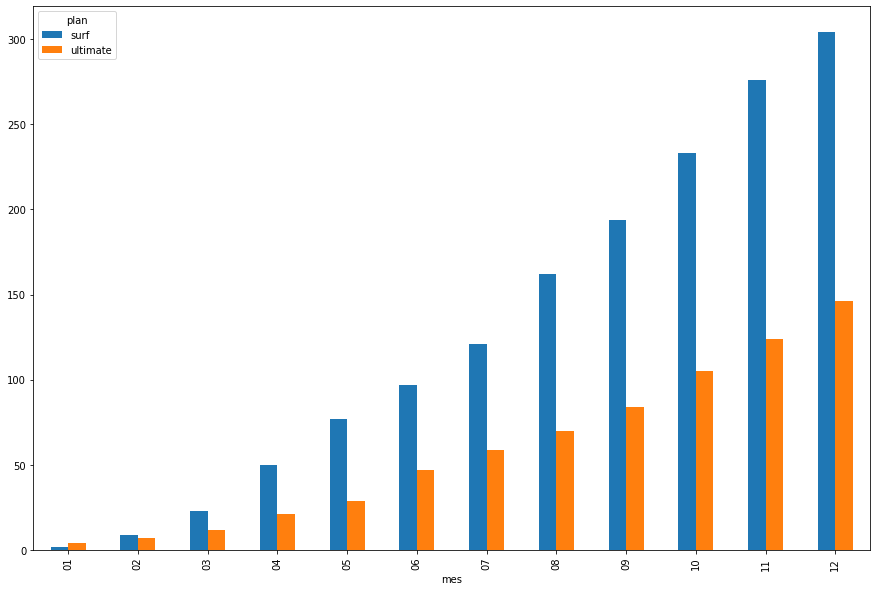

```python
consumo_usuarios2.pivot_table(index='mes', columns='plan', values='ingresos', aggfunc='count').plot(kind='bar', figsize=(15,10))
```

*Es importante considerar esto en los analisis posteriores ya que si analizamos por meses, los primeros meses pueden no reflejar la realidad debido a la reducidad cantidad de datos*

### Llamadas

| plan mes | surf | ultimate |
| --- | --- | --- |
| 01 | 203.000000 | 193.500000 |
| 02 | 297.000000 | 403.142857 |
| 03 | 330.000000 | 304.250000 |
| 04 | 351.540000 | 336.857143 |
| 05 | 399.584416 | 406.241379 |
| 06 | 431.298969 | 370.957447 |
| 07 | 449.983471 | 427.067797 |
| 08 | 410.111111 | 417.485714 |
| 09 | 414.226804 | 440.523810 |
| 10 | 428.768240 | 451.361905 |
| 11 | 424.601449 | 447.774194 |
| 12 | 475.657895 | 456.630137 |

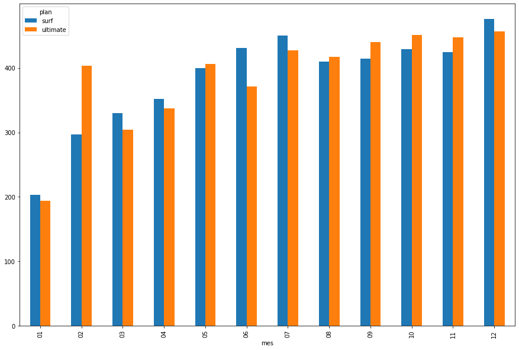

```python
# Comparamos la duración promedio de llamadas por cada plan por cada mes. Dibuja una gráfica de barras para visualizarlo.
mins_prom_xcalls= consumo_usuarios2.pivot_table(index='mes', columns='plan', values='duracion_redondeada', aggfunc='mean')
display(mins_prom_xcalls)
mins_prom_xcalls.plot(kind='bar', figsize=(15,10))
```

| plan | duracion_redondeada |
| --- | --- |
| surf | 428.804264 |
| ultimate | 430.151130 |

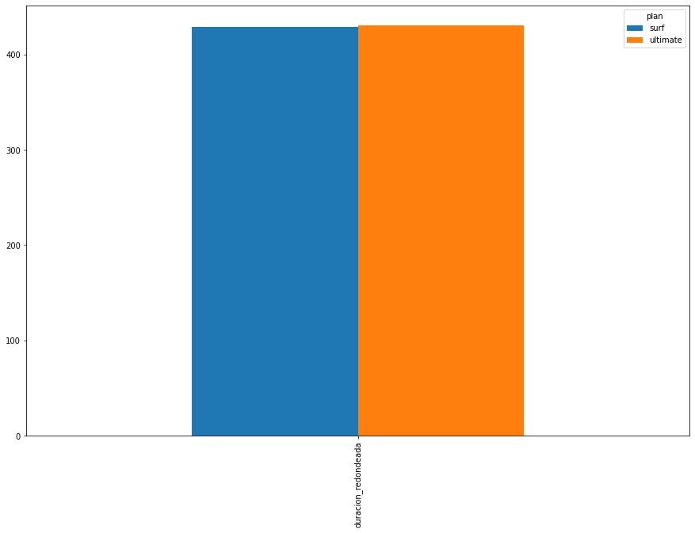

```python
#Duración promedio del total de llamadas por mes
consumo_usuarios2.pivot_table(columns='plan', values='duracion_redondeada', aggfunc='mean').plot(kind='bar', figsize=(15,10),color=[azul, naranja])
consumo_usuarios2.pivot_table(index='plan', values='duracion_redondeada', aggfunc='mean')
```

| user_id | plan mes | surf | ultimate |
| --- | --- | --- | --- |
| 1000 | 12 | NaN | 124.0 |
| 1001 | 08 | 182.0 | NaN |
|  | 09 | 315.0 | NaN |
|  | 10 | 393.0 | NaN |
|  | 11 | 426.0 | NaN |
| ... | ... | ... | ... |
| 1498 | 12 | 339.0 | NaN |
| 1499 | 09 | 346.0 | NaN |
|  | 10 | 385.0 | NaN |
|  | 11 | 308.0 | NaN |
|  | 12 | 496.0 | NaN |

2256 rows × 2 columns

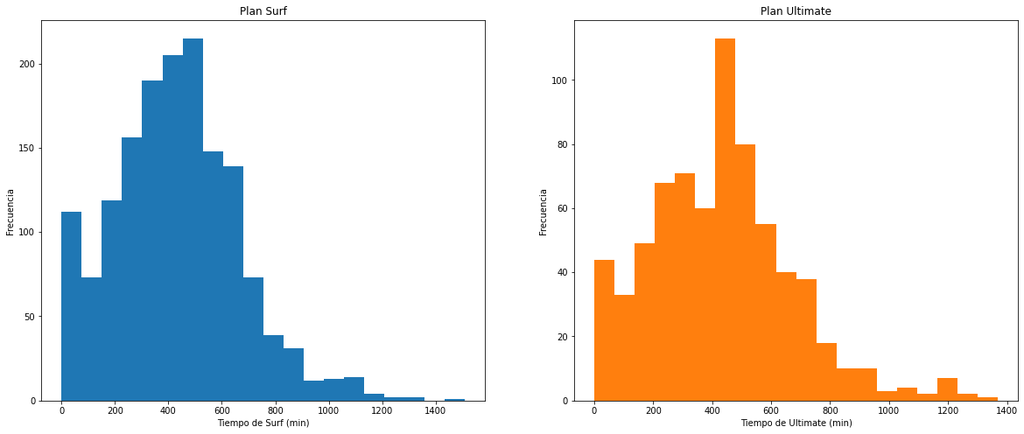

```python
# Comparamos el número de minutos que los usuarios de cada plan requieren cada mes. Traza un histograma.

mins_req= consumo_usuarios2.pivot_table(index=('user_id','mes'), columns='plan', values='duracion_redondeada', aggfunc=('sum'))
display(mins_req)

fig, (ax1, ax2) = plt.subplots(nrows=1, ncols=2, figsize=(20, 8))
ax1.hist(mins_req['surf'],bins=20)
ax2.hist(mins_req['ultimate'],bins=20, color=naranja)

ax1.set_xlabel('Tiempo de Surf (min)')
ax1.set_ylabel('Frecuencia')
ax1.set_title('Plan Surf')

ax2.set_xlabel('Tiempo de Ultimate (min)')
ax2.set_ylabel('Frecuencia')
ax2.set_title('Plan Ultimate')

plt.show()

#mins_req.plot(kind='hist', figsize=(15,10))
```

*Los histogramas anteriores muestran que la mayoria de las llamadas mensuales se encuentran alrededor de los 500 minutos, con una pocas llegando hasta los 1400 minutos al mes en ambos planes.*

```python
# Calculamos la media y la varianza de la duración mensual de llamadas.

def calc_var (series):
    variance = np.var(series)
    return variance

mean_var_calls= consumo_usuarios2.pivot_table(index=('plan'), values='duracion_redondeada', aggfunc=('mean',calc_var))
display(mean_var_calls)
```

| plan | calc_var | mean |
| --- | --- | --- |
| surf | 55298.997217 | 428.804264 |
| ultimate | 57986.388177 | 430.151130 |

Estadisticas duracion llamadas (Surf)

```
count    1548.000000
mean      428.804264
std       235.233380
min         0.000000
25%       271.000000
50%       425.000000
75%       576.000000
max      1510.000000
Name: duracion_redondeada, dtype: float64
```

Estadisticas duracion llamadas (Ultimate)

```
count     708.000000
mean      430.151130
std       240.973869
min         0.000000
25%       259.000000
50%       425.000000
75%       565.250000
max      1369.000000
Name: duracion_redondeada, dtype: float64
```

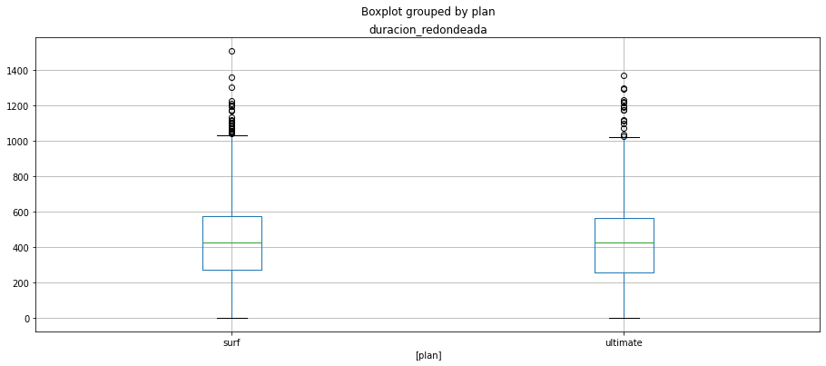

```python
# Trazamos un diagrama de caja para visualizar la distribución de la duración mensual de llamadas.

print_mejorado("Estadisticas duracion llamadas (Surf)",24)
print(consumo_usuarios2.query('plan=="surf"')['duracion_redondeada'].describe())
print_mejorado("Estadisticas duracion llamadas (Ultimate)",24)
print(consumo_usuarios2.query('plan=="ultimate"')['duracion_redondeada'].describe())

consumo_usuarios2.boxplot(column=['duracion_redondeada'],by=['plan'],figsize=(15,6))
```

*Los diagramas de caja respaldan lo que ya habiamos deducido antes. Ambos planes en cuanto a la duración de llamadas mensuales tienen una mediana muy similar al promedio, con algunos pocos usuarios atipicos que suelen hablar mas de 1000 minutos en un mes*

### Mensajes

| plan mes | surf | ultimate |
| --- | --- | --- |
| 01 | 10.500000 | 15.500000 |
| 02 | 12.000000 | 21.571429 |
| 03 | 15.260870 | 20.250000 |
| 04 | 17.400000 | 22.047619 |
| 05 | 24.012987 | 32.103448 |
| 06 | 25.298969 | 29.340426 |
| 07 | 27.033058 | 32.830508 |
| 08 | 28.777778 | 38.814286 |
| 09 | 30.762887 | 38.380952 |
| 10 | 33.682403 | 39.428571 |
| 11 | 32.583333 | 39.209677 |
| 12 | 38.703947 | 45.561644 |

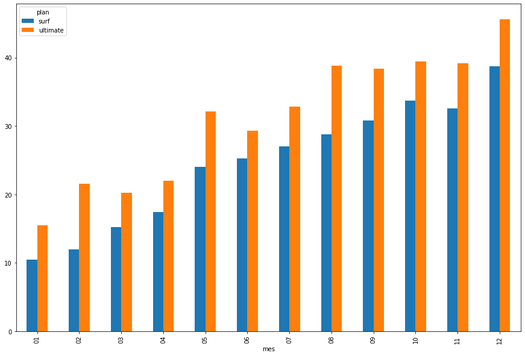

```python
# Compraramos el número de mensajes que tienden a enviar cada mes los usuarios de cada plan
cant_prom_mensajes= consumo_usuarios2.pivot_table(index='mes', columns='plan', values='num_mensajes', aggfunc='mean')
display(cant_prom_mensajes)
cant_prom_mensajes.plot(kind='bar', figsize=(15,10))
```

| plan | num_mensajes |
| --- | --- |
| surf | 31.111757 |
| ultimate | 37.798023 |

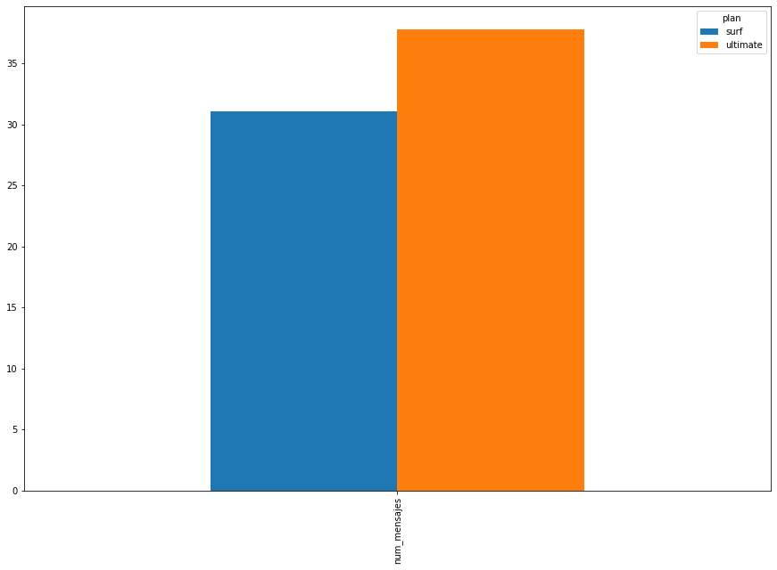

```python
#Duración promedio del total de llamadas por mes
consumo_usuarios2.pivot_table(columns='plan', values='num_mensajes', aggfunc='mean').plot(kind='bar', figsize=(15,10),color=[azul, naranja])
consumo_usuarios2.pivot_table(index='plan', values='num_mensajes', aggfunc='mean')
```

*Rspecto a los mensajes, tanto en los promedio por cada mes, como los promedios de todos los meses, vemos que los usuarios con el plan "Ultimate", suelen enviar mas mensajes de texto que los usuarios con el plan "Surf", en promedio, unos 7 mensajes mas al mes*

| user_id | plan mes | surf | ultimate |
| --- | --- | --- | --- |
| 1000 | 12 | NaN | 11.0 |
| 1001 | 08 | 30.0 | NaN |
|  | 09 | 44.0 | NaN |
|  | 10 | 53.0 | NaN |
|  | 11 | 36.0 | NaN |
| ... | ... | ... | ... |
| 1498 | 12 | 0.0 | NaN |
| 1499 | 09 | 0.0 | NaN |
|  | 10 | 0.0 | NaN |
|  | 11 | 0.0 | NaN |
|  | 12 | 0.0 | NaN |

2256 rows × 2 columns

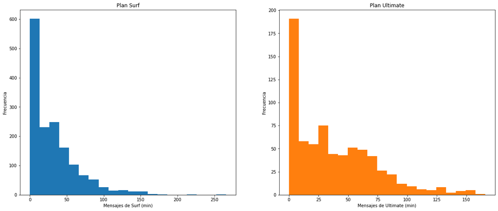

```python
# Comparamos el número de mensajes que los usuarios de cada plan requieren cada mes. Trazamos un histograma.

mensajes_req= consumo_usuarios2.pivot_table(index=('user_id','mes'), columns='plan', values='num_mensajes', aggfunc=('sum'))
display(mensajes_req)

fig, (ax1, ax2) = plt.subplots(nrows=1, ncols=2, figsize=(20, 8))
ax1.hist(mensajes_req['surf'],bins=20)
ax2.hist(mensajes_req['ultimate'],bins=20, color=naranja)

ax1.set_xlabel('Mensajes de Surf (min)')
ax1.set_ylabel('Frecuencia')
ax1.set_title('Plan Surf')

ax2.set_xlabel('Mensajes de Ultimate (min)')
ax2.set_ylabel('Frecuencia')
ax2.set_title('Plan Ultimate')

plt.show()

#mins_req.plot(kind='hist', figsize=(15,10))
```

*En los histogramas anteriores vemos que en ambos planes, un porcentaje considerable de usuarios envian menos de 10 mensajes al mes. Ademas, solo unos pocos usuarios del plan Ultimate envian muchos mensajes al mes, los cuales son los que estan subiendo la media de mensajes*

Numero de mensajes mensuales (Surf)

```
count    1548.000000
mean       31.111757
std        33.641112
min         0.000000
25%         3.000000
50%        24.000000
75%        47.000000
max       266.000000
Name: num_mensajes, dtype: float64
```

Numero de mensajes mensuales (Ultimate)

```
count    708.000000
mean      37.798023
std       34.896049
min        0.000000
25%        7.000000
50%       30.000000
75%       61.000000
max      166.000000
Name: num_mensajes, dtype: float64
```

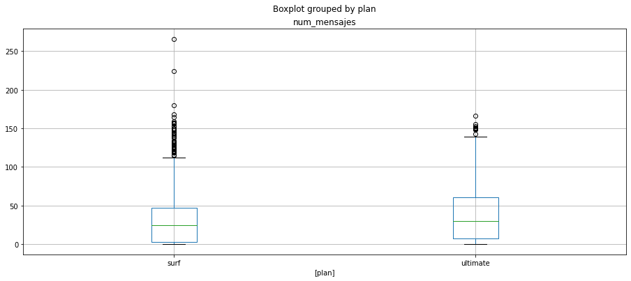

```python
# Trazamos un diagrama de caja para visualizar la distribución de numero mensual de mensajes

print_mejorado("Numero de mensajes mensuales (Surf)",24)
print(consumo_usuarios2.query('plan=="surf"')['num_mensajes'].describe())
print_mejorado("Numero de mensajes mensuales  (Ultimate)",24)
print(consumo_usuarios2.query('plan=="ultimate"')['num_mensajes'].describe())

consumo_usuarios2.boxplot(column=['num_mensajes'],by=['plan'],figsize=(15,6))
```

*Los graficos de caja muestran que en el plan surf hay algunos usuarios atipicos que envian ebtre 100 y 250 mensajes, pero la gran mayoria envia entre 0 y 100 mensajes. Mientras que los usuarios del plan Ultimate, suelen enviar entre 0 y 140 mensajes y solo un pequeño numoer de usuarios atipos envian mas que esta cantidad.*

### Internet

| plan mes | surf | ultimate |
| --- | --- | --- |
| 01 | 10.500000 | 15.500000 |
| 02 | 12.000000 | 21.571429 |
| 03 | 15.260870 | 20.250000 |
| 04 | 17.400000 | 22.047619 |
| 05 | 24.012987 | 32.103448 |
| 06 | 25.298969 | 29.340426 |
| 07 | 27.033058 | 32.830508 |
| 08 | 28.777778 | 38.814286 |
| 09 | 30.762887 | 38.380952 |
| 10 | 33.682403 | 39.428571 |
| 11 | 32.583333 | 39.209677 |
| 12 | 38.703947 | 45.561644 |

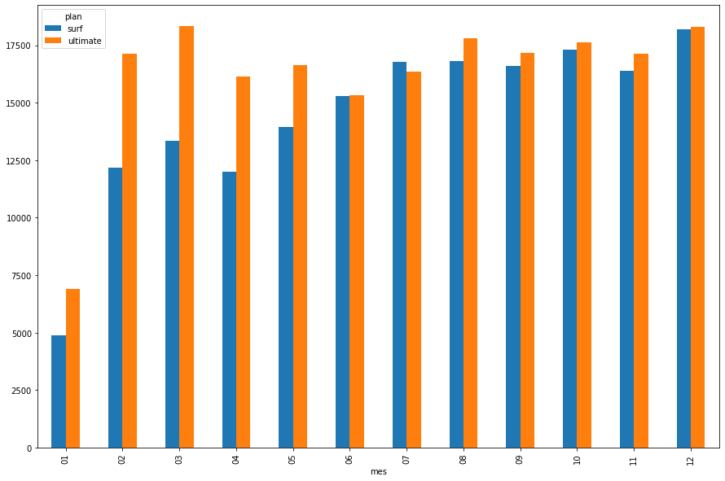

```python
# Comparamos la cantidad de tráfico de internet consumido por usuarios por plan
datos_prom_internet= consumo_usuarios2.pivot_table(index='mes', columns='plan', values='mb_used', aggfunc='mean')
display(cant_prom_mensajes)
datos_prom_internet.plot(kind='bar', figsize=(15,10))
```

| plan | mb_used |
| --- | --- |
| surf | 16560.312513 |
| ultimate | 17242.419379 |

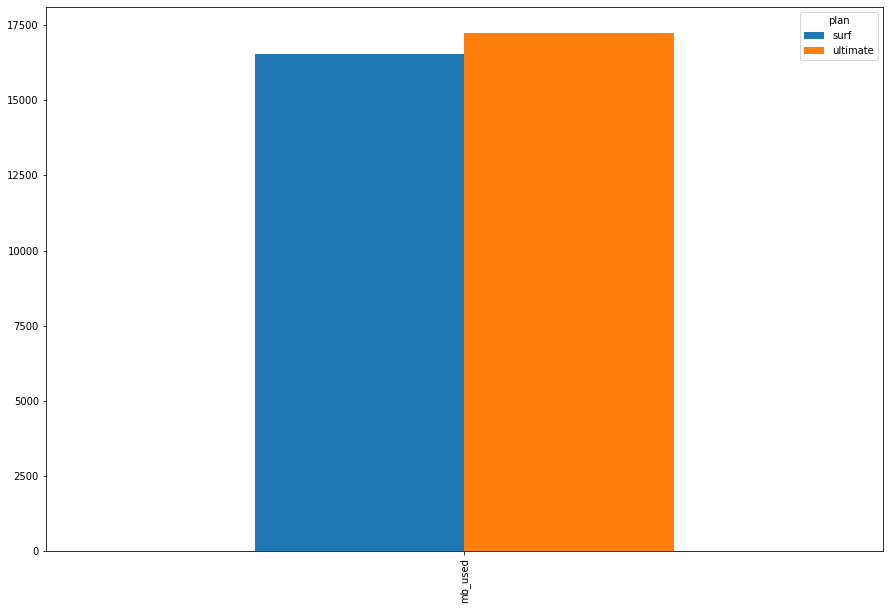

```python
#Datos promedio consumidos por mes

consumo_usuarios2.pivot_table(columns='plan', values='mb_used', aggfunc='mean').plot(kind='bar', figsize=(15,10),color=[azul, naranja])
consumo_usuarios2.pivot_table(index='plan', values='mb_used', aggfunc='mean')
```

| user_id | plan mes | surf | ultimate |
| --- | --- | --- | --- |
| 1000 | 12 | NaN | 1901.47 |
| 1001 | 08 | 6919.15 | NaN |
|  | 09 | 13314.82 | NaN |
|  | 10 | 22330.49 | NaN |
|  | 11 | 18504.30 | NaN |
| ... | ... | ... | ... |
| 1498 | 12 | 23137.69 | NaN |
| 1499 | 09 | 12984.76 | NaN |
|  | 10 | 19492.43 | NaN |
|  | 11 | 16813.83 | NaN |
|  | 12 | 22059.21 | NaN |

2256 rows × 2 columns

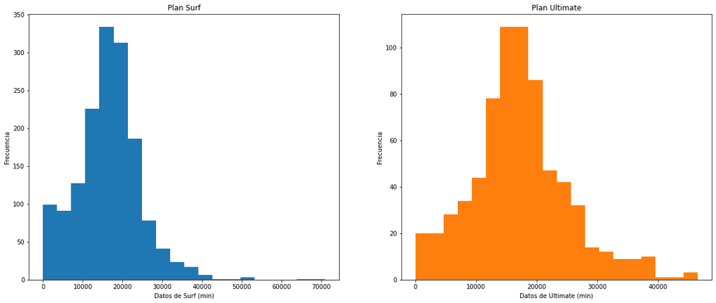

```python
# Comparamos el número de mensajes que los usuarios de cada plan requieren cada mes. Trazamos un histograma.

datos_req= consumo_usuarios2.pivot_table(index=('user_id','mes'), columns='plan', values='mb_used', aggfunc=('sum'))
display(datos_req)

fig, (ax1, ax2) = plt.subplots(nrows=1, ncols=2, figsize=(20, 8))
ax1.hist(datos_req['surf'],bins=20)
ax2.hist(datos_req['ultimate'],bins=20, color=naranja)

ax1.set_xlabel('Datos de Surf (min)')
ax1.set_ylabel('Frecuencia')
ax1.set_title('Plan Surf')

ax2.set_xlabel('Datos de Ultimate (min)')
ax2.set_ylabel('Frecuencia')
ax2.set_title('Plan Ultimate')

plt.show()
```

*En los histogramas anteriores vemos que la mayoria de los usuario de Surf suelen controlarse y no ocupar tantos datos, sin embargo, hay algunos (o un) valor atipico que con este plan esta consumiendo 70.000 Mb, y por consecuencia, subiendo la media de todo este grupo. Analizaremos en detalle los graficos de caja mas abajo.*

Consumo de datos mensuales (Surf)

```
count     1548.000000
mean     16560.312513
std       8006.513662
min          0.000000
25%      12040.765000
50%      16831.365000
75%      20992.482500
max      70931.590000
Name: mb_used, dtype: float64
```

Consumo de datos mensuales (Ultimate)

```
count      708.000000
mean     17242.419379
std       7883.455719
min          0.000000
25%      12671.450000
50%      16858.340000
75%      21096.085000
max      46595.330000
Name: mb_used, dtype: float64
```

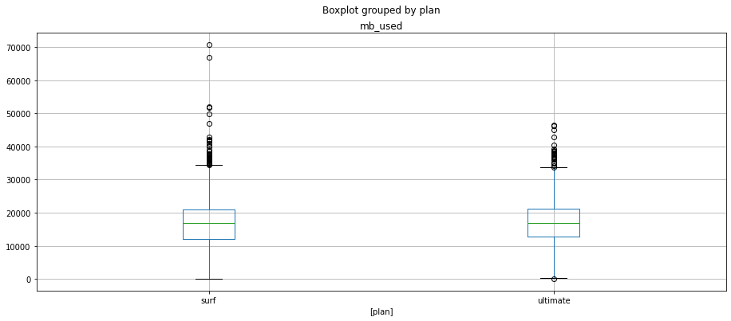

```python
# Trazamos un diagrama de caja para visualizar la distribución de numero mensual de mensajes

print_mejorado("Consumo de datos mensuales (Surf)",24)
print(consumo_usuarios2.query('plan=="surf"')['mb_used'].describe())
print_mejorado("Consumo de datos mensuales (Ultimate)",24)
print(consumo_usuarios2.query('plan=="ultimate"')['mb_used'].describe())

consumo_usuarios2.boxplot(column=['mb_used'],by=['plan'],figsize=(15,6))
```

```
(0.0, 35000.0)
```

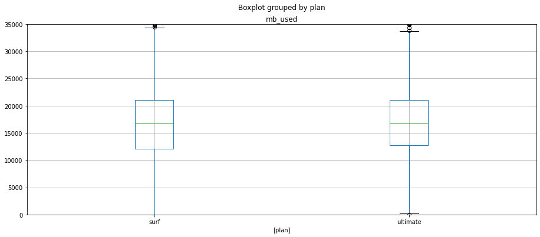

```python
consumo_usuarios2.boxplot(column=['mb_used'],by=['plan'],figsize=(15,6), )
plt.ylim(0, 35000)
```

*Los graficos de caja muestran que efectivamente en el pan surf hay un usurio que consumio mas de 70.000 mb en un mes y sube levemente la media de este grupo, dado que para ambos planes, la mediana ronda los 16.800 mb. Por otro lado, como ya dedujimos anteriomente, el uso de datos en el grupo Ultimate es ligeramente mas alto que el grupo Surf*

## Ingreso

[Del mismo modo en que has estudiado el comportamiento del usuario, es decir, estadísticamente, describe el ingreso entre los planes.]

| plan mes | surf | ultimate |
| --- | --- | --- |
| 01 | 20.000000 | 70.000000 |
| 02 | 34.396667 | 70.000000 |
| 03 | 45.941304 | 74.666667 |
| 04 | 40.710600 | 73.000000 |
| 05 | 47.628182 | 70.724138 |
| 06 | 49.276289 | 71.638298 |
| 07 | 62.674050 | 71.898305 |
| 08 | 63.931173 | 72.900000 |
| 09 | 58.271495 | 72.083333 |
| 10 | 65.570901 | 72.333333 |
| 11 | 58.207283 | 71.750000 |
| 12 | 70.429079 | 73.404110 |

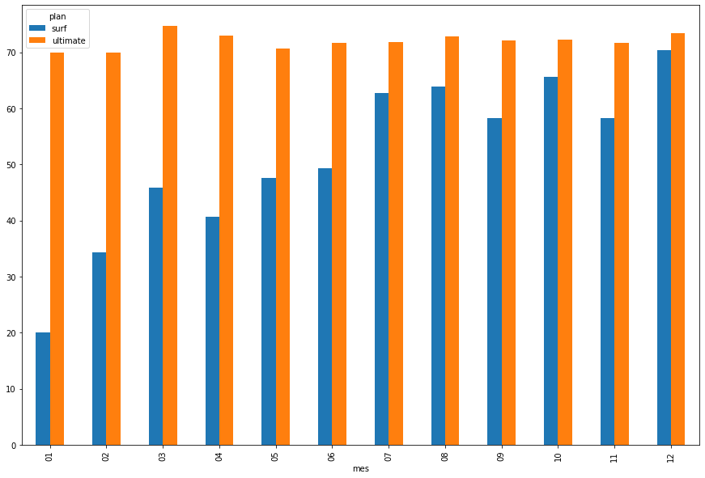

```python
# Comparamos la cantidad de ingresos por usuarios por plan
ingresos_prom= consumo_usuarios2.pivot_table(index='mes', columns='plan', values='ingresos', aggfunc='mean')
display(ingresos_prom)
ingresos_prom.plot(kind='bar', figsize=(15,10))
```

| plan | ingresos |
| --- | --- |
| surf | 60.650950 |
| ultimate | 72.353107 |

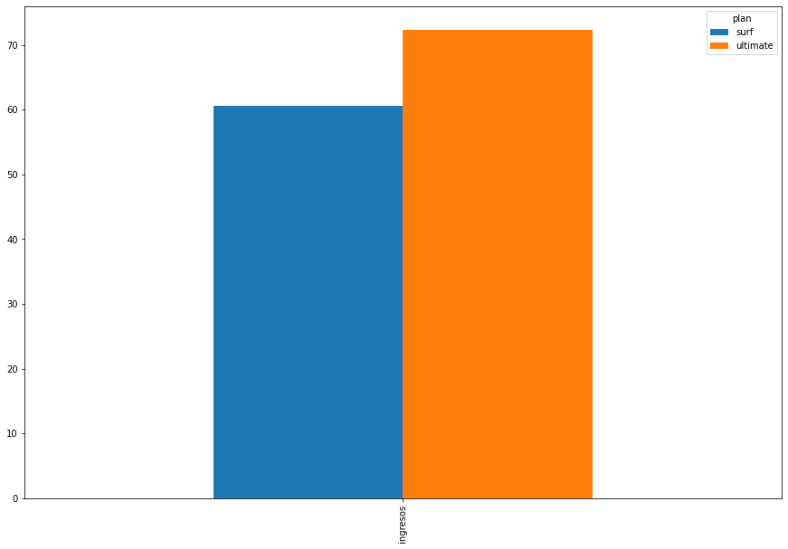

```python
#Ingresos promedio de usuarios individuales por mes

consumo_usuarios2.pivot_table(columns='plan', values='ingresos', aggfunc='mean').plot(kind='bar', figsize=(15,10),color=[azul, naranja])
consumo_usuarios2.pivot_table(index='plan', values='ingresos', aggfunc='mean')
```

*En promedio, el plan Ultimate, genera mas 12 USD app mas ingresos que el plan Surf*

| plan | ingresos |
| --- | --- |
| surf | 93887.67 |
| ultimate | 51226.00 |

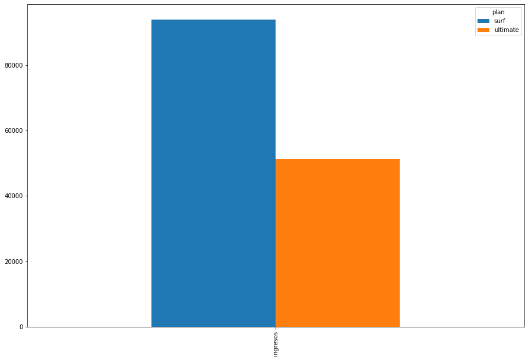

```python
#Ingresos totales por mes

consumo_usuarios2.pivot_table(columns='plan', values='ingresos', aggfunc='sum').plot(kind='bar', figsize=(15,10),color=[azul, naranja])
consumo_usuarios2.pivot_table(index='plan', values='ingresos', aggfunc='sum')
```

*Si bien, en promedio, los usuarios del plan Ultimate generan en promedio mas ingresos que los que tienen el plan Surf, analizando los ingresos generales, vemos que el plan Surf genera mas ingresos netos. Esto es debido a que durante el periodo analizado, hubo significativamente mas usuarios con el plan Surf que el Ultimate. Por consecuencia, a pesar de que independientemente este plan genera menos ingresos, al ser el mas contrado, es el que genera mas ingresos para la compañia*

| user_id | plan mes | surf | ultimate |
| --- | --- | --- | --- |
| 1000 | 12 | NaN | 1901.47 |
| 1001 | 08 | 6919.15 | NaN |
|  | 09 | 13314.82 | NaN |
|  | 10 | 22330.49 | NaN |
|  | 11 | 18504.30 | NaN |
| ... | ... | ... | ... |
| 1498 | 12 | 23137.69 | NaN |
| 1499 | 09 | 12984.76 | NaN |
|  | 10 | 19492.43 | NaN |
|  | 11 | 16813.83 | NaN |
|  | 12 | 22059.21 | NaN |

2256 rows × 2 columns

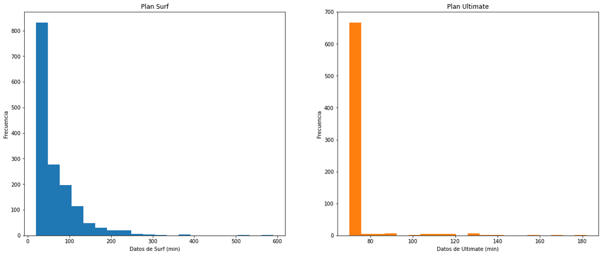

```python
# Comparamos el número de ingresos que los usuarios de cada plan generan cada mes. Trazamos un histograma.

ingresos_gen= consumo_usuarios2.pivot_table(index=('user_id','mes'), columns='plan', values='ingresos', aggfunc=('sum'))
display(datos_req)

fig, (ax1, ax2) = plt.subplots(nrows=1, ncols=2, figsize=(20, 8))
ax1.hist(ingresos_gen['surf'],bins=20)
ax2.hist(ingresos_gen['ultimate'],bins=20, color=naranja)

ax1.set_xlabel('Datos de Surf (min)')
ax1.set_ylabel('Frecuencia')
ax1.set_title('Plan Surf')

ax2.set_xlabel('Datos de Ultimate (min)')
ax2.set_ylabel('Frecuencia')
ax2.set_title('Plan Ultimate')

plt.show()
```

*Los histogramas anteriores pueden ser algo confusos pero representan exactamente lo que se concluye en el punto anterior*

Ingresos mensuales por usuario (Surf)

```
count    1548.000000
mean       60.650950
std        55.352905
min        20.000000
25%        20.000000
50%        40.420000
75%        80.307500
max       590.370000
Name: ingresos, dtype: float64
```

Ingresos mensuales por usuario (Ultimate)

```
count    708.000000
mean      72.353107
std       11.487385
min       70.000000
25%       70.000000
50%       70.000000
75%       70.000000
max      182.000000
Name: ingresos, dtype: float64
```

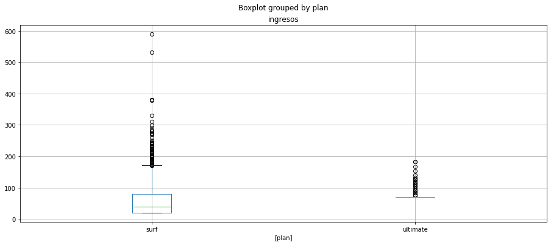

```python
# Trazamos un diagrama de caja para visualizar los ingresos individuales mensuales por usuario

print_mejorado("Ingresos mensuales por usuario (Surf)",24)
print(consumo_usuarios2.query('plan=="surf"')['ingresos'].describe())
print_mejorado("Ingresos mensuales por usuario (Ultimate)",24)
print(consumo_usuarios2.query('plan=="ultimate"')['ingresos'].describe())

consumo_usuarios2.boxplot(column=['ingresos'],by=['plan'],figsize=(15,6))
```

```
(0.0, 200.0)
```

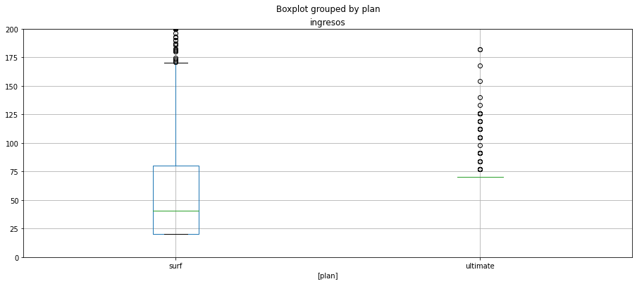

```python
consumo_usuarios2.boxplot(column=['ingresos'],by=['plan'],figsize=(15,6), )
plt.ylim(0, 200)
```

*Los graficos de caja muestran que el rango de ingresos por usuario con el plan Surf van entre los 20 y los 170 USD. Mientras que los usuarios del plan Ultimate, tipicamente solo pagan los 70 USD del plan y solo en casos atipicos terminan pagando mas*

## Probamos las hipótesis estadísticas.

**Hipotesis de ingresos**

Nuestro cliente nos solicita evaluar si es que existen diferencias entre los ingresos del plan Surf y los ingresos del plan Ultimate.

Para esto, planteamos nuestras hipostesis nula y alterna y verificamos la hipotesis nula. -La hipotesis nula es que el ingreso promedio de los planes Ultimate y Surf es igual  
-La hipotesis alterna es que el ingreso promedio de los planes Ultimate y Surf es diferente

```python
# Prueba las hipótesis
#La hipotesis nula es que el ingreso promedio de los planes Ultimate y Surf es igual
#La hipotesis alterna es que el ingreso promedio de los planes Ultimate y Surf es diferente

# ingresos de los usuarios por mes (Surf)
ingresos_surf = consumo_usuarios2.query('plan=="surf"')['ingresos']

# ingresos de los usuarios por mes (Ultimate)
ingresos_ultimate  = consumo_usuarios2.query('plan=="ultimate"')['ingresos']

#establecemos un nivel crítico de significación estadística (5%)
alpha = 0.05

# Probamos la hipótesis de que las medias de los ingresos de los dos planes son iguales
#nota: asumimos que la varianza es igual para ambos grupos
results = st.ttest_ind(ingresos_surf, ingresos_ultimate)


print('p-value:', results.pvalue)

if (results.pvalue < alpha): # tu código: compara los valores p obtenidos con el nivel de significación estadística
    print_mejorado("Rechazamos la hipótesis nula",20)
    print_mejorado("El ingreso promedio mensual  de los planes es diferente",24)
else:
    print_mejorado("No rechazamos la hipótesis nula",20)
    print_mejorado("El ingreso promedio mensual  de los planes es igual",24)
```

```
p-value: 2.8503869206973235e-08
```

Rechazamos la hipótesis nula

El ingreso promedio mensual de los planes es diferente

**Hipotesis de ingresos de las región de New York vs el resto de regiones**

Nuestro cliente nos solicita evaluar si es que existen diferencias entre los ingresos promedio de los usuarios en el área de estados Nueva York-Nueva Jersey al de los usuarios de otras regiones. Primero que todo vemos que ciudades/estados disponen nuestras tablas.

```python
#Creamos un dataframe con las regiones asociadas a cada usuario
regiones=data_users.pivot_table(index=('user_id'),values=('ciudades','estado'),aggfunc=('first'))
regiones.pivot_table(index=('ciudades','estado'),aggfunc=('first'))
```

| ciudades | estado |
| --- | --- |
| Albany-Schenectady-Troy | NY |
| Albuquerque | NM |
| Atlanta-Sandy Springs-Roswell | GA |
| Austin-Round Rock-Georgetown | TX |
| Bakersfield | CA |
| Baltimore-Columbia-Towson | MD |
| Baton Rouge | LA |
| Birmingham-Hoover | AL |
| Boston-Cambridge-Newton | MA-NH |
| Bridgeport-Stamford-Norwalk | CT |
| Buffalo-Cheektowaga | NY |
| Cape Coral-Fort Myers | FL |
| Charleston-North Charleston | SC |
| Charlotte-Concord-Gastonia | NC-SC |
| Chicago-Naperville-Elgin | IL-IN-WI |
| Cincinnati | OH-KY-IN |
| Cleveland-Elyria | OH |
| Colorado Springs | CO |
| Columbia | SC |
| Columbus | OH |
| Dallas-Fort Worth-Arlington | TX |
| Dayton-Kettering | OH |
| Denver-Aurora-Lakewood | CO |
| Detroit-Warren-Dearborn | MI |
| El Paso | TX |
| Fresno | CA |
| Grand Rapids-Kentwood | MI |
| Greensboro-High Point | NC |
| Houston-The Woodlands-Sugar Land | TX |
| Indianapolis-Carmel-Anderson | IN |
| Jacksonville | FL |
| Kansas City | MO-KS |
| Knoxville | TN |
| Las Vegas-Henderson-Paradise | NV |
| Los Angeles-Long Beach-Anaheim | CA |
| Louisville/Jefferson County | KY-IN |
| Memphis | TN-MS-AR |
| Miami-Fort Lauderdale-West Palm Beach | FL |
| Milwaukee-Waukesha | WI |
| Minneapolis-St. Paul-Bloomington | MN-WI |
| Nashville-Davidson–Murfreesboro–Franklin | TN |
| New Haven-Milford | CT |
| New Orleans-Metairie | LA |
| New York-Newark-Jersey City | NY-NJ-PA |
| North Port-Sarasota-Bradenton | FL |
| Oklahoma City | OK |
| Omaha-Council Bluffs | NE-IA |
| Orlando-Kissimmee-Sanford | FL |
| Oxnard-Thousand Oaks-Ventura | CA |
| Philadelphia-Camden-Wilmington | PA-NJ-DE-MD |
| Phoenix-Mesa-Chandler | AZ |
| Pittsburgh | PA |
| Portland-Vancouver-Hillsboro | OR-WA |
| Providence-Warwick | RI-MA |
| Raleigh-Cary | NC |
| Richmond | VA |
| Riverside-San Bernardino-Ontario | CA |
| Rochester | NY |
| Sacramento–Roseville–Folsom | CA |
| Salt Lake City | UT |
| San Antonio-New Braunfels | TX |
| San Diego-Chula Vista-Carlsbad | CA |
| San Francisco-Oakland-Berkeley | CA |
| San Jose-Sunnyvale-Santa Clara | CA |
| Seattle-Tacoma-Bellevue | WA |
| St. Louis | MO-IL |
| Stockton | CA |
| Tampa-St. Petersburg-Clearwater | FL |
| Tucson | AZ |
| Tulsa | OK |
| Urban Honolulu | HI |
| Virginia Beach-Norfolk-Newport News | VA-NC |
| Washington-Arlington-Alexandria | DC-VA-MD-WV |

**Nueva York y Nueva Jersey son dos estados distintos en los Estados Unidos. Newark, por otro lado, es una ciudad en Nueva Jersey, ubicada en el condado de Essex, que es parte del área metropolitana de Nueva York.**

**Es posible que a veces se utilice la nomenclatura "Nueva York-Newark-Nueva Jersey" para hacer referencia a la región o área metropolitana que abarca partes de ambos estados y la ciudad de Newark. Esta área metropolitana se conoce comúnmente como la "Área Tri-Estatal" o la "Área Metropolitana de Nueva York".**

En base a esto, y según lo solicitado por nuestro cliente, las ciudades de interes son **New York-Newark-Jersey City** asociadas a los estados de **NY-NJ-PA**

```python
#Creamos un ultimo Dataset que considere las ciudades de los usuarios
consumo_usuarios3=consumo_usuarios2.join(regiones, on=['user_id'])
consumo_usuarios3
```

| user_id | mes | num_llamadas | duracion_redondeada | num_mensajes | mb_used | plan | ingresos | ciudades | estado |
| --- | --- | --- | --- | --- | --- | --- | --- | --- | --- |
| 1000 | 12 | 16.0 | 124.0 | 11.0 | 1901.47 | ultimate | 70.00 | Atlanta-Sandy Springs-Roswell | GA |
| 1001 | 08 | 27.0 | 182.0 | 30.0 | 6919.15 | surf | 20.00 | Seattle-Tacoma-Bellevue | WA |
|  | 09 | 49.0 | 315.0 | 44.0 | 13314.82 | surf | 20.00 | Seattle-Tacoma-Bellevue | WA |
|  | 10 | 65.0 | 393.0 | 53.0 | 22330.49 | surf | 90.09 | Seattle-Tacoma-Bellevue | WA |
|  | 11 | 64.0 | 426.0 | 36.0 | 18504.30 | surf | 60.00 | Seattle-Tacoma-Bellevue | WA |
| ... | ... | ... | ... | ... | ... | ... | ... | ... | ... |
| 1498 | 12 | 39.0 | 339.0 | 0.0 | 23137.69 | surf | 100.00 | New York-Newark-Jersey City | NY-NJ-PA |
| 1499 | 09 | 41.0 | 346.0 | 0.0 | 12984.76 | surf | 20.00 | Orlando-Kissimmee-Sanford | FL |
|  | 10 | 53.0 | 385.0 | 0.0 | 19492.43 | surf | 70.00 | Orlando-Kissimmee-Sanford | FL |
|  | 11 | 45.0 | 308.0 | 0.0 | 16813.83 | surf | 40.00 | Orlando-Kissimmee-Sanford | FL |
|  | 12 | 65.0 | 496.0 | 0.0 | 22059.21 | surf | 90.00 | Orlando-Kissimmee-Sanford | FL |

2256 rows × 8 columns

*El cliente nos solicito evaluar si el ingreso promedio de los usuarios en el área de estados Nueva York-Nueva Jersey es diferente al de los usuarios de otras regiones. Sin embargo, no especifico si queria un analisis considerando el plan de los usuarios o no. Es por esto que procederé a analizar 3 hipotesis. Las cuales vemos a continuación:*

**Hipotesis 1**

Plan Surf  
-La hipotesis nula es que el ingreso promedio de los usuarios de NY-NJ-PA con el plan Surf es igual al de otras areas  
-La hipotesis alterna es que el ingreso promedio de los usuarios de NY-NJ-PA con el plan Surf es diferente al de otras areas

```python
#Hipótesis
#La hipotesis nula es que el ingreso promedio de los usuarios de NY-NJ-PA con el plan Surf es igual al de otras areas
#La hipotesis alterna es que el ingreso promedio de los usuarios de NY-NJ-PA con el plan Surf es diferente al de otras areas

# ingresos de los usuarios de NY-NJ-PA (Plan Surf)
ingresos_NY_surf = consumo_usuarios3.query('ciudades=="New York-Newark-Jersey City" and plan=="surf"')['ingresos']

#ingresos de los usuarios de otras regiones (Plan Surf)
ingresos_otros_surf  = consumo_usuarios3.query('ciudades!="New York-Newark-Jersey City" and plan=="surf"')['ingresos']

#establecemos un nivel crítico de significación estadística (5%)
alpha = 0.05

# Probamos la hipótesis de que las medias de los ingresos de los dos planes son iguales
#nota: asumimos que la varianza es igual para ambos grupos
results = st.ttest_ind(ingresos_NY_surf, ingresos_otros_surf)


print('p-value:', results.pvalue)

if (results.pvalue < alpha): # tu código: compara los valores p obtenidos con el nivel de significación estadística
    print_mejorado("Rechazamos la hipótesis nula",20)
    print_mejorado("El ingreso promedio mensual (Surf) entre las regiones de NY-NJ-PA y otras regiones es la misma",24)
else:
    print_mejorado("No rechazamos la hipótesis nula",20)
    print_mejorado("El ingreso promedio mensual (Surf) entre las regiones de NY-NJ-PA y otras regiones es diferente",24)
```

```
p-value: 0.16738246887800834
```

No rechazamos la hipótesis nula

**Hipotesis 2**

Plan Ultimate  
-La hipotesis nula es que el ingreso promedio de los usuarios de NY-NJ-PA con el plan Ultimate es igual al de otras areas  
-La hipotesis alterna es que el ingreso promedio de los usuarios de NY-NJ-PA con el plan Ultimate es diferente al de otras areas

```python
#Hipótesis
#La hipotesis nula es que el ingreso promedio de los usuarios de NY-NJ-PA con el plan Ultimate es igual al de otras areas
#La hipotesis alterna es que el ingreso promedio de los usuarios de NY-NJ-PA con el plan Ultimate es diferente al de otras areas

# ingresos de los usuarios de NY-NJ-PA (Plan Ultimate)
ingresos_NY_ultimate = consumo_usuarios3.query('ciudades=="New York-Newark-Jersey City" and plan=="ultimate"')['ingresos']

#ingresos de los usuarios de otras regiones (Plan Ultimate)
ingresos_otros_ultimate = consumo_usuarios3.query('ciudades!="New York-Newark-Jersey City" and plan=="ultimate"')['ingresos']

#establecemos un nivel crítico de significación estadística (5%)
alpha = 0.05

# Probamos la hipótesis de que las medias de los ingresos de los dos planes son iguales
#nota: asumimos que la varianza es igual para ambos grupos
results = st.ttest_ind(ingresos_NY_ultimate, ingresos_otros_ultimate)


print('p-value:', results.pvalue)

if (results.pvalue < alpha): # tu código: compara los valores p obtenidos con el nivel de significación estadística
    print_mejorado("Rechazamos la hipótesis nula",20)
    print_mejorado("El ingreso promedio mensual (Ultimate) entre las regiones de NY-NJ-PA y otras regiones es la misma",24)
else:
    print_mejorado("No rechazamos la hipótesis nula",20)
    print_mejorado("El ingreso promedio mensual (Ultimate) entre las regiones de NY-NJ-PA y otras regiones es diferente",24)
```

```
p-value: 0.05539238782374058
```

No rechazamos la hipótesis nula

**Hipotesis 3**

Ambos planes -La hipotesis nula es que el ingreso promedio de los usuarios de NY-NJ-PA es igual al de otras areas  
-La hipotesis alterna es que el ingreso promedio de los usuarios de NY-NJ-PA es diferente al de otras areas

```python
#Hipótesis
#La hipotesis nula es que el ingreso promedio de los usuarios de NY-NJ-PA es igual al de otras areas
#La hipotesis alterna es que el ingreso promedio de los usuarios de NY-NJ-PA es diferente al de otras areas

# ingresos de los usuarios de NY-NJ-PA
ingresos_NY = consumo_usuarios3.query('ciudades=="New York-Newark-Jersey City"')['ingresos']

#ingresos de los usuarios de otras regiones
ingresos_otros  = consumo_usuarios3.query('ciudades!="New York-Newark-Jersey City"')['ingresos']

#establecemos un nivel crítico de significación estadística (5%)
alpha = 0.05

# Probamos la hipótesis de que las medias de los ingresos de los dos planes son iguales
#nota: asumimos que la varianza es igual para ambos grupos
results = st.ttest_ind(ingresos_NY, ingresos_otros)


print('p-value:', results.pvalue)

if (results.pvalue < alpha): # tu código: compara los valores p obtenidos con el nivel de significación estadística
    print_mejorado("Rechazamos la hipótesis nula",20)
    print_mejorado("El ingreso promedio mensual entre las regiones de NY-NJ-PA y otras regiones es la misma",24)
else:
    print_mejorado("No rechazamos la hipótesis nula",20)
    print_mejorado("El ingreso promedio mensual entre las regiones de NY-NJ-PA y otras regiones es diferente",24)
```

```
p-value: 0.04693355751103774
```

Rechazamos la hipótesis nula

## Conclusión general

*- Vimos que al comienzo del año hubo muy pocos usuarios con planes contrados y a medida que va avanzando el año, mas usuarios se fueron sumando. En el mes de Enero hubo aproximadamente solo 10 usuarios, mientras que en Diciembre, entre los dos planes hubo mas de 400 usuarios.*

*LLAMADAS*

-El plan "surf" fue contratado por mas personas, debido probablemente a que es mas economico.

-Los promedios de la duracion total de llamadas mensuales para ambos planes 435 minutos.

-La mayoria de las llamadas mensuales se encuentran alrededor de los 500 minutos, y solo unos poco usuarios atipicos hablar mas de 1000 minutos al mes en ambos planes.

*MENSAJES*

-Los usuarios con el plan "Ultimate", suelen enviar promedio mas por mensajes de texto que los usuarios con el plan "Surf", en promedio, unos 7 mensajes mas al mes

-Para ambos planes, un porcentaje considerable de usuarios envian menos de 10 mensajes al mes

-Los usuarios del plan Surf suelen enviar entre 0 y 100 mensajes y solo un pequeño numero usuarios atipicos que envian entre 100 y 250 mensajes.

-Los usuarios del plan Ultimate, suelen enviar entre 0 y 140 mensajes y solo un pequeño numero de usuarios atipicos envian mas que esta cantidad.

*INTERNET*

Los usuario de Surf suelen controlarse y no ocupar tantos datos como los usuarios de Ultimate

Para el plan surf hubo usuario que consumio mas de 70.000 mb en un mes y sube levemente la media de ese grupo

La mediana para ambos planes ronda los 16.800 mb. pero la media para el plan ultimate es levemente mas alta

*INGRESOS*

-En promedio, el plan Ultimate, genera mas 12 USD app mas ingresos que el plan Surf

-Los usuarios del plan Ultimate generan en promedio mas ingresos que los que tienen el plan Surf, PERO los usuarios del plan Surf generan mas ingresos en general. Esto es debido a que durante el periodo analizado, hubo significativamente mas usuarios con el plan Surf que el Ultimate. Por consecuencia, a pesar de que independientemente este plan genera menos ingresos, al ser el mas contratado, es el que genero mas ingresos para la compañia durante el año 2018***

-El rango de ingresos por usuario con el plan Surf van entre los 20 y los 170 USD.

- Los usuarios del plan Ultimate, tipicamente solo pagan los 70 USD del plan y solo en casos atipicos terminan pagando mas

*HIPOTESIS EVALUADAS*

**Hipotesis de ingresos**  
Nuestro cliente nos solicitó evaluar si es que existen diferencias entre los ingresos del plan Surf y los ingresos del plan Ultimate.

Se concluye que el **ingreso mensual de los usuarios es diferente entre los planes Surf y Ultimate**

**Hipotesis de ingresos de las región de New York vs el resto de regiones**  
Nuestro cliente nos solicita evaluar si es que existen diferencias entre los ingresos promedio de los usuarios en el área de estados Nueva York-Nueva Jersey al de los usuarios de otras regiones.

Se concluye que:

-El ingreso promedio mensual (Ultimate) entre las regiones de NY-NJ-PA y otras regiones es la misma